# Population analysis

In this script, we load the population data and compute summary statistics and visualisations.

## Set directories

### Add repositories to path

The assumed folder structure is

- [[your local folder]/repositories/attention-parietal-dopamine](https://gitlab.com/JvK/attention-parietal-dopamine)
- [[your local folder]/repositories/plotj](https://github.com/jochemvankempen/plotj)
- [[your local folder]/repositories/gain-variability](https://github.com/jochemvankempen/gain-variability)
- [[your local folder]/data/processed](https://gin.g-node.org/jochemvankempen/Thiele-attention-gratc-LIP-pipette)
- [your local folder]/data/analysed (created in batch_analyses.m)
- [your local folder]/data/population (created in this script)

```matlab
% set your local path

% add folders to path
addpath(genpath(fullfile(path_wd,'/repositories/attention-parietal-dopamine')))
addpath(genpath(fullfile(path_wd,'/repositories/plotj')))
addpath(genpath(fullfile(path_wd,'/repositories/gain-variability')))
```

### Data directories

Set data directories

```matlab
subjects = {'W','J'};
path_data = fullfile(path_wd,'data/processed');
path_population = regexprep(path_data,'processed','population');

if ~isfolder(path_population)
    mkdir(path_population)
end

fprintf('Load data from: %s\n', path_data)
```

Load data from: M:\Jochem\papers\2021-DA-LIP\data\processed

```matlab
fprintf('Save data to: %s\n', path_population)
```

Save data to: M:\Jochem\papers\2021-DA-LIP\data\population

## Param

set some parameters that we'll use

```matlab
label_drug = {'Dopamine','SCH23390'};
label_drug_ext = {'',' (D1-antagonist)'};
label_attention = {'Attend RF','Attend away'};
label_drug_onoff = {'Drug on','Drug off'};
label_unitclass = {'Narrow','Broad'};

markersize = 15; % scatterplot markersize

plot_conventions = 'Science'; % follow figure conventions from this journal

% condition indices
idx_attention_cond = [1 0 0 1 0 0]; % cond_num mapping to attend RF/away in trialdata
idx_attention_roc = [1 1 0 1 1 0]; % see condition comparisons in spike_rate_ROC.m

% select units selective for task feature, e.g. attention or drug selective
% selectivity_criterium = 'none';
% selectivity_criterium = 'dru';
% selectivity_criterium = 'dru';
% selectivity_criterium = 'att';
selectivity_criterium = 'att&dru';
```

## Get recordinglist

Compile list of recordings from recinfo.mat in each session folder

```matlab
recordinglist = get_recordinglist(subjects, path_data);
fprintf('Loaded %d recordings \n', height(recordinglist))
```

Loaded 47 recordings

## Get population data

Compile population data matrices/tables

```matlab
[rate_summary, unitlist] = get_population_data(recordinglist, 'spike_rate_summary', path_data, 'dim', 'block_change(1-Inf)');
rate_PSTH = get_population_data(recordinglist, 'spike_rate_PSTH', path_data, 'dim');
rate_ANOVA = get_population_data(recordinglist, 'spike_rate_ANOVA', path_data, 'dim');
rate_ROC = get_population_data(recordinglist, 'spike_rate_ROC', path_data, 'dim', 'block_change(1-Inf)');
waveform = get_population_data(recordinglist, 'waveform', path_data);

RT = get_population_data(recordinglist, 'RT_drug_modulation', path_data, 'stim');
```

## Extract param

```matlab
num_rec = size(RT.RT,1);
[num_unit, num_drug, num_cond] = size(rate_summary.rate);

fprintf('Loaded %d units \n',num_unit)
```

Loaded 88 units

## Classify cells as narrow or broad spiking

```matlab
waveform_cutoff = 250;

unit_class = cell(num_unit,1);
unit_class(waveform.peak_to_trough_time <= waveform_cutoff) = {'Narrow'};
unit_class(waveform.peak_to_trough_time > waveform_cutoff) = {'Broad'};

% fill and define as categorical variable
unitlist.peak_to_trough_time = waveform.peak_to_trough_time;
unitlist.unit_class = categorical(unit_class, 'Ordinal', false);
unitlist.unit_class = reordercats(unitlist.unit_class, label_unitclass);

unitlist.waveform = waveform.waveform;

waveform_time = waveform.time;

clear waveform unit_class
```

## Append unitlist

```matlab
% rename units in sequential order to be able to join to later tables
unitlist.unit = categorical((1:num_unit)', 'Ordinal', false);

% average over the ejection currents from both barrels
unitlist.EjectCurrent = nanmean(unitlist.EjectCurrent,2);
unitlist.EjectCurrent_centered = unitlist.EjectCurrent - mean(unique(unitlist.EjectCurrent));

% append/join with selectivity/ANOVA table
unitlist = join(unitlist, rate_ANOVA.selectivity, 'Keys', 'unit');

% define categorical variables
unitlist.Drug = categorical(cellstr(unitlist.Drug), 'Ordinal', false);
unitlist.Subject = categorical(cellstr(unitlist.Subject), 'Ordinal', false);

% define datetime variables
unitlist.Date = datetime(unitlist.Date, 'Format', "yyyy-MM-dd");
```

## Create population tables: attention

table for attention conditions, including drug on/off

```matlab
% number of elements in table
t_numel = num_unit*num_drug*2;

% compute attention averages
t_rate(:,:,1) = mean(rate_summary.rate(:,:,idx_attention_cond==1),3);
t_rate(:,:,2) = mean(rate_summary.rate(:,:,idx_attention_cond==0),3);

t_FF(:,:,1) = mean(rate_summary.FF(:,:,idx_attention_cond==1),3);
t_FF(:,:,2) = mean(rate_summary.FF(:,:,idx_attention_cond==0),3);

t_PSTH(:,:,1,:) = mean(rate_PSTH.samples(:,:,idx_attention_cond==1,:),3);
t_PSTH(:,:,2,:) = mean(rate_PSTH.samples(:,:,idx_attention_cond==0,:),3);

t_gain = arrayfun(@(x)(x.rhat),rate_ROC.gv,'UniformOutput',true);
t_gain_log = log(t_gain);
t_gv = rate_ROC.gv;

% use idx_attention_roc for ROC and MI, not that this is different from the
% other attention index.
t_roc_attend(:,:,1) = mean(rate_ROC.roc_attend(:,:,idx_attention_roc==1),3);
t_roc_attend(:,:,2) = mean(rate_ROC.roc_attend(:,:,idx_attention_roc==0),3);

t_mi_attend(:,:,1) = mean(rate_ROC.mi_attend(:,:,idx_attention_roc==1),3);
t_mi_attend(:,:,2) = mean(rate_ROC.mi_attend(:,:,idx_attention_roc==0),3);

% create metadata columns
[t_att] = deal(zeros(size(t_rate)));
t_att(:,:,1) = 1;

t_unit = categorical((1:num_unit)', 'Ordinal', false);
t_unit = repmat(t_unit, [1, num_drug, 2]);

t_drug_on = [0 1];
t_drug_on = repmat(t_drug_on, [num_unit, 1, 2]);

t_unit      = reshape(t_unit, [t_numel, 1]);
t_drug_on   = reshape(t_drug_on, [t_numel, 1]);
t_att       = reshape(t_att, [t_numel, 1]);

[t_att_label,t_drug_on_label] = deal(cell(length(t_att),1));
t_att_label(t_att==1) = {'Attend RF'};
t_att_label(t_att==0) = {'Attend away'};

t_drug_on_label(t_drug_on==0) = {'Drug off'};
t_drug_on_label(t_drug_on==1) = {'Drug on'};

% reshape matrices to single columns
t_rate          = reshape(t_rate, [t_numel, 1]);
t_FF            = reshape(t_FF, [t_numel, 1]);
t_roc_attend    = reshape(t_roc_attend, [t_numel, 1]);
t_mi_attend     = reshape(t_mi_attend, [t_numel, 1]);
t_gain          = reshape(t_gain, [t_numel, 1]);
t_gain_log      = reshape(t_gain_log, [t_numel, 1]);
t_gv            = reshape(t_gv, [t_numel, 1]);

t_PSTH          = reshape(t_PSTH, [t_numel, length(rate_PSTH.time)]);

% build table
att_table = table(...
    t_unit, ...
    t_drug_on_label, t_att_label, ...
    t_rate, t_FF, ... % rate, FF
    t_roc_attend, t_mi_attend, t_gain, t_gain_log, t_gv, ... % roc, MI, gain, gain_log, GainVariability
    t_PSTH, ... % PSTH
    'VariableNames', {'unit', 'drug_on', 'attention', 'rate', 'FF', 'roc', 'MI', 'gain', 'gain_log', 'gv', 'PSTH'});

% join tables
att_table = join(att_table, unitlist, 'Keys', 'unit');

% define categorical variables
att_table.drug_on = categorical(att_table.drug_on, 'Ordinal', false);
att_table.attention = categorical(att_table.attention, 'Ordinal', false);

% reorder categories to label_* order
att_table.drug_on = reordercats(att_table.drug_on, label_drug_onoff);
att_table.attention = reordercats(att_table.attention, label_attention);

% define combined classes
att_table.attention_drug_on = att_table.attention .* att_table.drug_on;
att_table.attention_drug_on = categorical(regexprep(cellstr(att_table.attention_drug_on), ' Drug', ', Drug')); % add a comma in between classes

% clear temporary variables
clear t_*

% print head
fprintf('att_table:\n')
```

att_table:

```matlab
disp(head(att_table))
```

**unit** **drug_on** **attention** **rate** **FF** **roc** **MI** **gain** **gain_log** **gv** **PSTH** **Subject** **Task** **Date** **Drug** **EjectCurrent** **Weight** **peak_to_trough_time** **unit_class** **waveform** **EjectCurrent_centered** **s_stim** **s_att** **s_dru** **s_dir** **s_att*dru** **s_att*dir** **s_dru*dir** **s_att*dru*dir** **attention_drug_on** **____** **________** **_________** **______** **______** **_______** **________** **________** **________** **_____________________** **_______________** **_______** **_____** **__________** **________** **____________** **______** **___________________** **__________** **______________** **_____________________** **__________** **__________** **__________** **__________** **_________** **_________** **_________** **_____________** **___________________** 1 Drug off Attend RF 8.2778 2.1547 0.6376 0.12527 0.14343 -1.9419 [1×1 GainVariability] [1×1251 double] W gratc 2015-05-21 Dopamine 25 9.29 345.6 Broad [1×187 double] -34.25 0.6978 0.0023999 0.57272 0.83275 0.55229 0.52515 0.30834 0.64143 Attend RF, Drug off 2 Drug off Attend RF 8.8506 1.4285 0.70263 0.17977 NaN NaN [1×1 GainVariability] [1×1251 double] W gratc 2015-05-21 Dopamine 25 9.29 205.2 Narrow [1×187 double] -34.25 0.79882 5.7922e-14 0.16206 0.25224 0.027989 0.54777 0.21153 0.20304 Attend RF, Drug off 3 Drug off Attend RF 23.394 3.7531 0.66866 0.12168 0.11193 -2.1899 [1×1 GainVariability] [1×1251 double] W gratc 2015-05-21 Dopamine 25 9.29 388.8 Broad [1×187 double] -34.25 0.05165 4.2769e-08 0.45615 0.31594 0.054758 0.42777 0.44512 0.26137 Attend RF, Drug off 4 Drug off Attend RF 11.453 1.8759 0.64466 0.11753 0.065949 -2.7189 [1×1 GainVariability] [1×1251 double] W gratc 2015-05-28 Dopamine 60 NaN 394.2 Broad [1×187 double] 0.75 0.29917 1.5365e-08 0.98854 0.90503 0.1141 0.97673 0.61297 0.38682 Attend RF, Drug off 5 Drug off Attend RF 28.963 5.2381 0.61176 0.088129 0.18975 -1.662 [1×1 GainVariability] [1×1251 double] W gratc 2015-05-29 Dopamine 80 NaN 183.6 Narrow [1×187 double] 20.75 2.0498e-22 6.6763e-07 0.0087419 0.88981 0.43338 0.71566 0.67429 0.44351 Attend RF, Drug off 6 Drug off Attend RF 44.259 7.4757 0.73118 0.19062 0.13876 -1.975 [1×1 GainVariability] [1×1251 double] W gratc 2015-06-03 Dopamine 75 9 302.4 Broad [1×187 double] 15.75 5.3262e-45 2.8411e-14 0.00011895 0.74406 0.24956 0.68049 0.2666 0.1016 Attend RF, Drug off 7 Drug off Attend RF 24.173 2.6038 0.73431 0.1636 0.065311 -2.7286 [1×1 GainVariability] [1×1251 double] W gratc 2015-06-03 Dopamine 75 9 329.4 Broad [1×187 double] 15.75 1.8937e-29 2.2529e-13 0.011994 0.00099457 0.80152 0.022988 0.93706 0.83731 Attend RF, Drug off 8 Drug off Attend RF 12.152 5.0028 0.57967 0.14417 0.33173 -1.1034 [1×1 GainVariability] [1×1251 double] W gratc 2015-06-04 Dopamine 90 8 291.6 Broad [1×187 double] 30.75 7.4239e-14 0.00078848 0.075078 0.043667 0.91433 0.34239 0.58849 0.20115 Attend RF, Drug off

```matlab
% save to csv file for R analysis
table_selectivity = get_unit_selectivity(att_table, selectivity_criterium);
R_table = att_table(table_selectivity,:);
R_table = removevars(R_table,{'gv','PSTH','waveform'});
writetable(R_table, fullfile(path_population,sprintf('population_attention_%s.csv',selectivity_criterium)))
```

## drug table

table for analysis results that are computed for each attention condition, across drug conditions. There are thus no separate drug_on conditions in this table.

```matlab
% number of elements in table
t_numel = num_unit*2;

% compute attention averages
t_roc_drug(:,1) = mean(rate_ROC.roc_drug(:,idx_attention_cond==1),2);
t_roc_drug(:,2) = mean(rate_ROC.roc_drug(:,idx_attention_cond==0),2);

t_mi_drug(:,1) = mean(rate_ROC.mi_drug(:,idx_attention_cond==1),2);
t_mi_drug(:,2) = mean(rate_ROC.mi_drug(:,idx_attention_cond==0),2);

t_roc_drug = reshape(t_roc_drug, [t_numel, 1]);
t_mi_drug = reshape(t_mi_drug, [t_numel, 1]);

% create metadata columns
t_unit = categorical((1:num_unit)', 'Ordinal', false);
t_unit = repmat(t_unit, [2, 1]);

t_cond = repmat(1:2,[num_unit 1]);

t_cond_label = cell(size(t_cond));
t_cond_label(:,1) = {'Attend RF'};
t_cond_label(:,2) = {'Attend away'};
t_cond_label = reshape(t_cond_label, [t_numel, 1]);

% build table
drug_table = table(...
    t_unit, ...
    t_cond_label, ...
    t_roc_drug, t_mi_drug, ... % roc, MI
    'VariableNames', {'unit', 'attention', 'roc', 'MI'});

% join tables
drug_table = join(drug_table, unitlist, 'Keys', 'unit');

% define categorical variables
drug_table.attention = categorical(drug_table.attention, 'Ordinal', false);

% reorder categories to label_* order
drug_table.attention = reordercats(drug_table.attention, label_attention);

% clear temporary variables
clear t_* rate_*

% print head
fprintf('drug_table:\n')
```

drug_table:

```matlab
disp(head(drug_table))
```

**unit** **attention** **roc** **MI** **Subject** **Task** **Date** **Drug** **EjectCurrent** **Weight** **peak_to_trough_time** **unit_class** **waveform** **EjectCurrent_centered** **s_stim** **s_att** **s_dru** **s_dir** **s_att*dru** **s_att*dir** **s_dru*dir** **s_att*dru*dir** **____** **_________** **_______** **__________** **_______** **_____** **__________** **________** **____________** **______** **___________________** **__________** **______________** **_____________________** **__________** **__________** **__________** **__________** **_________** **_________** **_________** **_____________** 1 Attend RF 0.48333 0.00010785 W gratc 2015-05-21 Dopamine 25 9.29 345.6 Broad [1×187 double] -34.25 0.6978 0.0023999 0.57272 0.83275 0.55229 0.52515 0.30834 0.64143 2 Attend RF 0.60052 0.085384 W gratc 2015-05-21 Dopamine 25 9.29 205.2 Narrow [1×187 double] -34.25 0.79882 5.7922e-14 0.16206 0.25224 0.027989 0.54777 0.21153 0.20304 3 Attend RF 0.60693 0.068293 W gratc 2015-05-21 Dopamine 25 9.29 388.8 Broad [1×187 double] -34.25 0.05165 4.2769e-08 0.45615 0.31594 0.054758 0.42777 0.44512 0.26137 4 Attend RF 0.57284 0.038441 W gratc 2015-05-28 Dopamine 60 NaN 394.2 Broad [1×187 double] 0.75 0.29917 1.5365e-08 0.98854 0.90503 0.1141 0.97673 0.61297 0.38682 5 Attend RF 0.44499 -0.034453 W gratc 2015-05-29 Dopamine 80 NaN 183.6 Narrow [1×187 double] 20.75 2.0498e-22 6.6763e-07 0.0087419 0.88981 0.43338 0.71566 0.67429 0.44351 6 Attend RF 0.36805 -0.097646 W gratc 2015-06-03 Dopamine 75 9 302.4 Broad [1×187 double] 15.75 5.3262e-45 2.8411e-14 0.00011895 0.74406 0.24956 0.68049 0.2666 0.1016 7 Attend RF 0.39486 -0.053193 W gratc 2015-06-03 Dopamine 75 9 329.4 Broad [1×187 double] 15.75 1.8937e-29 2.2529e-13 0.011994 0.00099457 0.80152 0.022988 0.93706 0.83731 8 Attend RF 0.48523 -0.08402 W gratc 2015-06-04 Dopamine 90 8 291.6 Broad [1×187 double] 30.75 7.4239e-14 0.00078848 0.075078 0.043667 0.91433 0.34239 0.58849 0.20115

## Print summary of data

```matlab
% all units
fprintf('UNITS\n')
```

UNITS

```matlab
fprintf('\tRecorded %d units\n', height(unitlist))
```

Recorded 88 units

```matlab
% units per subject
fprintf('SUBJECTS\n')
```

SUBJECTS

```matlab
M1 = unitlist.Subject==subjects{1};
M2 = unitlist.Subject==subjects{2};
fprintf('\tRecorded %d/%d units from monkey 1/2\n', length(find(M1)), length(find(M2)))
```

Recorded 64/24 units from monkey 1/2

```matlab
% unit selectivity (visual/attention)
fprintf('SELECTIVITY\n')
```

SELECTIVITY

```matlab
unit_selectivity = get_unit_selectivity(unitlist, 'visual');
selective_visual = length(find(unit_selectivity));
fprintf('\t%d units with visual response (%1.1f%%)\n', selective_visual, selective_visual/num_unit*100)
```

76 units with visual response (86.4%)

```matlab
unit_selectivity = get_unit_selectivity(unitlist, 'att');
selective_attention = length(find(unit_selectivity));
fprintf('\t%d units with attentional modulation (%1.1f%%)\n', selective_attention, selective_attention/num_unit*100)
```

74 units with attentional modulation (84.1%)

```matlab
% units and unit selectivity per drug
fprintf('DRUG\n')
```

DRUG

```matlab
selective_drug = 0;
selective_attdrug = 0;
selective_interaction = 0;
for idrug = 1:length(label_drug)

    num_drug_units = unitlist.Drug==label_drug(idrug); % total units recorded with this drug

    unit_selectivity = get_unit_selectivity(unitlist, 'dru',{'drug',label_drug(idrug)});

    fprintf('\tRecorded %d/%d (%d) units from monkey (1/2) with %s\n', length(find(M1 & num_drug_units)), length(find(M2 & num_drug_units)), length(find(num_drug_units)), label_drug{idrug})
    fprintf('\t-----------------------------------------------------------\n')
    selective_drug = selective_drug+length(find(unit_selectivity));
    fprintf('\t%d units modulated by %s (%1.1f%%)\n', length(find(unit_selectivity)), label_drug{idrug}, length(find(unit_selectivity))/length(find(num_drug_units))*100)

    unit_selectivity = get_unit_selectivity(unitlist, 'att&dru',{'drug',label_drug(idrug)});
    selective_attdrug = selective_attdrug+length(find(unit_selectivity));
    fprintf('\t%d units modulated by attention and drug %s (%1.1f%%)\n', length(find(unit_selectivity)), label_drug{idrug}, length(find(unit_selectivity))/length(find(num_drug_units))*100)

    unit_selectivity = get_unit_selectivity(unitlist, 'att*dru',{'drug',label_drug(idrug)});
    selective_interaction = selective_interaction+length(find(unit_selectivity));
    fprintf('\t%d units interaction with attention %s (%1.1f%%)\n', length(find(unit_selectivity)), label_drug{idrug}, length(find(unit_selectivity))/length(find(num_drug_units))*100)
end
```

Recorded 41/18 (59) units from monkey (1/2) with Dopamine

-----------------------------------------------------------

36 units modulated by Dopamine (61.0%)

31 units modulated by attention and drug Dopamine (52.5%)

4 units interaction with attention Dopamine (6.8%)

Recorded 23/6 (29) units from monkey (1/2) with SCH23390

-----------------------------------------------------------

14 units modulated by SCH23390 (48.3%)

14 units modulated by attention and drug SCH23390 (48.3%)

5 units interaction with attention SCH23390 (17.2%)

```matlab
% unit summary
fprintf('SUMMARY\n')
```

SUMMARY

```matlab
fprintf('\t%d total units modulated by attention  (%1.1f%%)\n', selective_attention, selective_attention/num_unit*100)
```

74 total units modulated by attention (84.1%)

```matlab
fprintf('\t%d total units modulated by drug application  (%1.1f%%)\n', selective_drug, selective_drug/num_unit*100)
```

50 total units modulated by drug application (56.8%)

```matlab
fprintf('\t%d total units modulated by drug application and attention  (%1.1f%%)\n', selective_attdrug, selective_attdrug/num_unit*100)
```

45 total units modulated by drug application and attention (51.1%)

```matlab
fprintf('\t%d total units interaction attention by drug application  (%1.1f%%)\n', selective_interaction, selective_interaction/num_unit*100)
```

9 total units interaction attention by drug application (10.2%)

```matlab
%
```

## Plot population histogram and example unit

[interactive chart not shown]

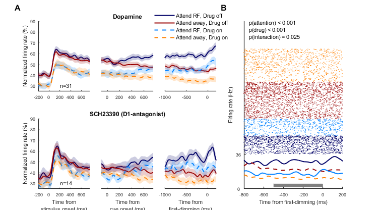

```matlab
[colors, labels] = get_colors('att_drug');
colors = reshape(colors, [4,3]);
labels = reshape(labels, [4,1]);

linestyle = {'-','-','--','--'};

events = {'stim', 'cue', 'dim'};
label_event = {'Stimulus onset', 'Cue onset', 'First-dimming'};
xlabel_event = {{'Time from','stimulus onset (ms)'}, {'Time from','cue onset (ms)'}, {'Time from','first-dimming (ms)'}};
xlim2use = {[-200 750], [-100 750], [-1000 200]};
ylim2use = [25 90];
ncol = length(label_event) + 2;
nrow = length(label_drug);

idx_subplot = {1,2,3,6,7,8,[4 5 9 10]};

[fH, fSet] = plotj_initFig('width', 20, 'height', 11, 'Journal',plot_conventions);
fSet.subplotGap2 = fSet.subplotGap .* [1.3 0.30];

iplot = 0;
for irow = 1:nrow

    idx_unit = get_unit_selectivity(att_table, selectivity_criterium, {'drug',label_drug(irow)});

    clear h
    for ievent = 1:length(label_event)
        iplot = iplot+1;

        rate_PSTH = get_population_data(recordinglist, 'spike_rate_PSTH', path_data, events{ievent});

        times = rate_PSTH.time;

        % convert samples to att_table format
        t_numel = num_unit*num_drug*2;
        clear t_PSTH
        t_PSTH(:,:,1,:) = mean(rate_PSTH.samples(:,:,idx_attention_cond==1,:),3);
        t_PSTH(:,:,2,:) = mean(rate_PSTH.samples(:,:,idx_attention_cond==0,:),3);
        t_PSTH          = reshape(t_PSTH, [t_numel, length(times)]);

        % initialise axes
        subtightplot(nrow, ncol, idx_subplot{iplot}, fSet.subplotGap2, fSet.subplotMargin, fSet.subplotMargin)
        if ievent==1 && irow==1
            plotj_initAx(fSet, 'axlabel', irow, 'axlabelDisplacement', [0.07, 0.00]);
        else
            plotj_initAx(fSet);
        end

        if ievent==(ceil(length(label_event)/2))
            ht = title([label_drug{irow} label_drug_ext{irow}], 'FontSize', fSet.Fontsize_title);
            %             ht.Position = ht.Position + [0.05 0 0];
        end
        if (ievent~=1)
            axh = get(gca);
            axh.YTick = [];
            axh.YAxis.Visible = 'off'; % remove y-axis
            %             axes('Color','none','YColor','none')
            %             set(gca,'xtick',[])
        end
        hold on

        % plot each attention and drug condition
        icol = 0;
        conditions = categories(att_table.attention_drug_on);
        for iatt_drug = 1:length(conditions)

            idx_att_drug = att_table.attention_drug_on==labels{iatt_drug};

            idx = idx_unit & idx_att_drug;

            icol = icol+1;
            h(icol) = boundedline(times, ...
                squeeze(mean(t_PSTH(idx,:),1)), ...
                squeeze(std(t_PSTH(idx,:),[],1))/sqrt(length(find(idx))), ...
                'cmap', colors(iatt_drug,:), 'alpha');
            set(h(icol), 'LineWidth', fSet.LineWidth)
            set(h(icol), 'LineStyle', linestyle{iatt_drug})

        end
        xlim(xlim2use{ievent})
        ylim(ylim2use)

        if ievent==1
            ylabel('Normalized firing rate (%)', 'FontSize', fSet.Fontsize_text)

            text(200, 30, sprintf('n=%d', length(find(idx))))
        elseif ievent==3
            if 0%irow==1
                hleg = legend(h, labels, 'FontSize', fSet.Fontsize_text, 'Box', 'Off');
                hleg.Position = hleg.Position + [0.05 0.15 0 0];
            end
        end

        if irow==nrow
            xlabel(xlabel_event{ievent}, 'FontSize', fSet.Fontsize_text)
        end
    end


end
hleg = legend(h, labels, 'FontSize', fSet.Fontsize_text, 'Box', 'Off', 'Location', 'NorthWest');
hleg.Position = hleg.Position + [-0.04 0.53 0 0];


% plot example cell, plot raster for example cell, only drug/attention

% plot param
iplot = iplot+1;
axH = subtightplot(nrow, ncol, idx_subplot{iplot}, fSet.subplotGap, fSet.subplotMargin, fSet.subplotMargin);
hold on
plotj_initAx(fSet, 'axlabel', 2, 'axlabelDisplacement', [0.07, 0.00]);
yoffset = 100;

[colors] = get_colors('att_drug');

% load data for single unit
event2plot = 3;
rec2plot = {'W','2015-10-01'};
unit2plot = [41 1];

idx_unit = unitlist.Subject==rec2plot{1} ...
    & unitlist.Date==rec2plot{2} ...
    & unitlist.unit==categorical(unit2plot(1));

loadfilename = fullfile(path_data, string(unitlist.Subject(idx_unit)), string(unitlist.Date(idx_unit)), 'unit.mat');
unit = load(loadfilename);
loadfilename = fullfile(path_data, string(unitlist.Subject(idx_unit)), string(unitlist.Date(idx_unit)), 'trialdata.mat');
load(loadfilename);
% [trialdata, unit] = remove_excluded_trials(trialdata, unit, unit2plot);

% select only trial window for which this unit has spikes
sps = unit.Dim1Align;

% raster for each condition
idx_attend = idx_attention_cond([trialdata.cond_num])';
idx_drug = [trialdata.drug]' + 1;
ymax = 0;
icond = 0;
for iatt = 1:length(unique(idx_attention_cond))
    for idrug = 1:2
        icond = icond+1;

        % get trial indices
        trial_index = (...
            idx_drug==idrug) ...
            & abs(idx_attend-2)==iatt;

        % compute raster
        [xspikes, yspikes] = spike_raster( sps(:,trial_index), xlim2use{event2plot}, unit2plot(2));

        % get PSTH
        x = rate_PSTH.time;
        y = squeeze(mean(rate_PSTH.samples(idx_unit,idrug,abs(idx_attention_cond-2)==iatt,:),3));

        % plot
        h(icol) = plot(x, y, 'Color', colors(iatt,idrug,:), 'linew', fSet.LineWidth, 'LineStyle', linestyle{icond});
        plot(xspikes, yspikes+yoffset+ymax, 'Color', colors(iatt,idrug,:), 'linew', 1.5)

        % set y-offset for next iteration
        ymax = ymax + max(yspikes(:));
    end
end
plot([-500 0], [10 10], 'Color', [0.5 0.5 0.5], 'linew', 5)
set(gca,'YTick',[0 yoffset],'YTicklabel',[0 round(rate_PSTH.maxhist(idx_unit)*1000)]);
xlabel('Time from first-dimming (ms)', 'FontSize', fSet.Fontsize_text)
ylabel('Firing rate (Hz)', 'FontSize', fSet.Fontsize_text)

xlim([-800 200])
ylim2use = yoffset+ymax+80;
ylim([0 ylim2use])

% set text in plot
p = [unitlist.s_att(idx_unit) unitlist.s_dru(idx_unit) unitlist.("s_att*dru")(idx_unit)];
[pstring,starstring] = get_significance_strings(p, 'rounded', 0, 'factorstring', {'attention', 'drug', 'interaction'});
text(axH, -750, ylim2use*0.95, pstring, 'FontSize', fSet.Fontsize_text)

% save
savefigname = fullfile(path_population, sprintf('Population_hist'));
plotj_saveFig(savefigname, {'png', 'svg'})
```

```matlab
%
```

## Violin, population plot

-----------------------------------------------------------------------

Testing model: Dopamine

Found 31 units

-----------------------------------------------------------------------

**Fixed effect coefficients: DFMethod = 'Residual', Alpha = 0.05** Name Estimate SE tStat DF pValue Lower Upper {'(Intercept)' } 19.132 2.7502 6.9564 120 1.9744e-10 13.687 24.577 {'drug_on_Drug on' } -2.3639 0.38775 -6.0964 120 1.3585e-08 -3.1316 -1.5962 {'attention_Attend RF' } 2.6939 0.38775 6.9476 120 2.0643e-10 1.9262 3.4616 {'drug_on_Drug on:attention_Attend RF'} -0.2884 0.38775 -0.74379 120 0.45846 -1.0561 0.47931

-----------------------------------------------------------------------

Testing model: SCH23390

Found 14 units

-----------------------------------------------------------------------

**Fixed effect coefficients: DFMethod = 'Residual', Alpha = 0.05** Name Estimate SE tStat DF pValue Lower Upper {'(Intercept)' } 15.922 2.6476 6.014 52 1.8299e-07 10.61 21.235 {'drug_on_Drug on' } -1.3651 0.44484 -3.0688 52 0.0034106 -2.2578 -0.47248 {'attention_Attend RF' } 2.5624 0.44484 5.7602 52 4.5931e-07 1.6697 3.455 {'drug_on_Drug on:attention_Attend RF'} -0.16397 0.44484 -0.36861 52 0.71391 -1.0566 0.72866

[interactive chart not shown]

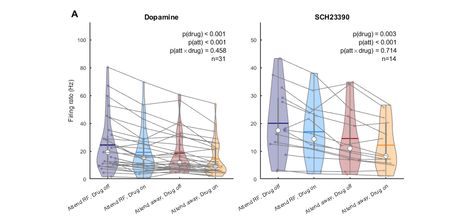

```matlab
data2plot = {'rate'};
% data2plot = {'FF'};
% data2plot = {'gain_log'};
% data2plot = {'gain'};
% data2plot = {'rate','FF'};

[colors_violin, labels_violin] = get_colors('att_drug');
colors_violin = reshape(colors_violin, [4,3]);
labels_violin = reshape(labels_violin, [4,1]);

% plotting param
ncol = 2 * length(data2plot); % drugs
nrow = 1;
iplot = 0;

[fH, fSet] = plotj_initFig('figNum', 2, 'width', 20, 'height', 10 * length(data2plot), 'Journal',plot_conventions);
fSet.subplotGap = [0.1, 0.06];
fSet.subplotMargin = [0.2, 0.1];

for idp = 1:length(data2plot)


    for idrug = 1:num_drug

        % fit model
        fprintf('\n-----------------------------------------------------------------------\n')
        fprintf('Testing model: %s \n', label_drug{idrug})

        idx_unit = get_unit_selectivity(att_table, selectivity_criterium, {'drug',label_drug(idrug)});
        num_unit_plot = length(unique(att_table.unit(idx_unit)));
        fprintf('\t Found %d units \n',  num_unit_plot)
        fprintf('-----------------------------------------------------------------------\n')

        % plot violinplot
        iplot = iplot+1;

        % init axes
        subtightplot(nrow, ncol, iplot, fSet.subplotGap, fSet.subplotMargin, fSet.subplotMargin)
        if idrug==1
            axH = plotj_initAx(fSet, 'axlabel', iplot, 'axlabelDisplacement', [0.05, 0.02]);
        else
            axH = plotj_initAx(fSet);
        end
        hold on

        h_title = title(label_drug{idrug}, 'FontSize', fSet.Fontsize_title);

        % extract smaller table
        %         v_att_table = unstack(att_table(idx_unit,:), data2plot{idp}, {'attention_drug_on'}, 'GroupingVariables', {'unit','unit_class'}, 'VariableNamingRule', 'preserve');
        v_att_table = att_table(idx_unit, ismember(att_table.Properties.VariableNames, {data2plot{idp},'drug_on','attention','unit','attention_drug_on'}));

        % plot violin
        v = violinplot(v_att_table.(data2plot{idp}), v_att_table.attention_drug_on, 'ShowMean', true);
        XTickLabel = get(gca,'XTickLabel');
        for iv = 1:length(v)
            v(iv).ScatterPlot.SizeData = 10;
            idx = strcmpi(XTickLabel(iv), labels_violin);
            v(iv).ViolinColor = colors_violin(idx,:);
        end

        % plot lines for each unit
        [data_x, data_y] = deal(NaN(num_unit_plot, length(length(v))));
        for iv = 1:length(v)
            if ~any(isnan(v_att_table.(data2plot{idp})))
                % works if data is complete
                data_x(:,iv) = v(iv).ScatterPlot.XData;
                data_y(:,iv) = v(iv).ScatterPlot.YData;
            else
                % catch if nan values are present
                idx = strcmpi(XTickLabel(iv), labels_violin);

                idx_trial = v_att_table.attention_drug_on==labels_violin{idx};
                data_x(:,iv) = iv;
                data_y(:,iv) = v_att_table.(data2plot{idp})(idx_trial);
            end
        end
        plot(data_x', data_y', 'Color', [0.5 0.5 0.5 0.3]);

        % fit model
        lme_population = fitlme(v_att_table,[data2plot{idp} ' ~ 1 + attention*drug_on + (1|unit)'],'DummyVarCoding','effects'); % fit interaction model with effect coding
        coefficients = lme_population.Coefficients;
        disp(coefficients)

        p_val = coefficients.pValue(2:end);
        p_string = get_significance_strings(p_val, 'rounded', 0, 'factorstring', {'drug','att',sprintf('att%sdrug', '\times')});
        p_string{end+1} = sprintf('n=%d',num_unit_plot);

        % plot text
        YLIM = get(gca,'ylim');
        set(gca, 'ylim', YLIM .* [1 1.25])

        tmp_x = get(gca,'xlim');
        tmp_y = get(gca,'ylim');

        x_pos = get_value_range(tmp_x, 0.95);
        y_pos = get_value_range(tmp_y, 0.85);

        h_text = text(x_pos, y_pos, p_string,'HorizontalAlignment','right');

        if idrug==1
            switch data2plot{idp}
                case 'rate'
                    ylabel('Firing rate (Hz)', 'FontSize', fSet.Fontsize_text)
                case 'FF'
                    ylabel('Fano Factor', 'FontSize', fSet.Fontsize_text)
                case 'gain'
                    ylabel('Gain variability', 'FontSize', fSet.Fontsize_text)
            end
        end
%         set(gca,'XTickLabelRotation',-15)
    end
end
```

## plot histogram cell-widths

[interactive chart not shown]

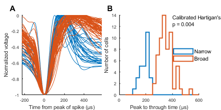

```matlab
colors = get_colors('spikewidth');

binsize = 25;
binedges = 50:binsize:600;

assert(any(ismember(binedges,waveform_cutoff)), 'threshold needs to be included in binedges')

[fH, fSet] = plotj_initFig('width', 12, 'height', 6, 'Journal',plot_conventions);
fSet.subplotGap = fSet.subplotGap .* [1 0.8];

ncol=2;
nrow=1;

subtightplot(nrow, ncol, 1, fSet.subplotGap, fSet.subplotMargin, fSet.subplotMargin)
plotj_initAx(fSet, 'axlabel', 1, 'axlabelDisplacement', [0.07, 0.01]);
hold on

x = waveform_time-(7*6*5.4);
plot(x, unitlist.waveform(unitlist.unit_class=='Narrow',:)*-1, 'Color', [colors(1,:) 0.5])
plot(x, unitlist.waveform(unitlist.unit_class=='Broad',:)*-1, 'Color', [colors(2,:) 0.5])

xlabel(['Time from peak of spike (' plotj_symbol('mu') 's)'], 'FontSize', fSet.Fontsize_text)
ylabel(['Normalized voltage'], 'FontSize', fSet.Fontsize_text)

xlim(minmax(waveform_time)+[0 -200]-7*6*5.4)
axis square

subtightplot(nrow, ncol, 2, fSet.subplotGap, fSet.subplotMargin, fSet.subplotMargin)
plotj_initAx(fSet, 'axlabel', 2, 'axlabelDisplacement', [0.07, 0.01]);
hold on

h = plotj_hist({unitlist.peak_to_trough_time(unitlist.unit_class=='Narrow'), unitlist.peak_to_trough_time(unitlist.unit_class=='Broad')}, ...
    'bins', binedges, ...
    'EdgeColor', colors, ...
    'histstyle', 'stairs',...
    'plotmean', 0, ...
    'LineWidth', fSet.LineWidth);

xlabel(['Peak to through time (' char(181) 's)'], 'FontSize', fSet.Fontsize_text)
ylabel('Number of cells', 'FontSize', fSet.Fontsize_text)
axis square

hleg = legend(h, {'Narrow','Broad'}, 'FontSize', fSet.Fontsize_text, 'Box', 'Off', 'AutoUpdate', 'Off', 'Location', 'East');
hleg.Position = hleg.Position + [0.08 0 0 0];

% do hartigan's dip test to see whether there is a significant dip in this distribution
% [dip, p_value, xlow,xup]=HartigansDipSignifTest(allSpikeWaveform.width(idx_unit),5000);
[dip, p_value, xlow, xup, boot_dip]=CalibratedHartigansDipSignifTest(unitlist.peak_to_trough_time, 10000);


p_string = get_significance_strings(p_value, 'round', 0);
h_text(1) = text(400, 13, {'Calibrated Hartigan''s dip test:', p_string}, 'FontSize', fSet.Fontsize_text);

savefigname = fullfile(path_population, sprintf('Population_broadNarrow'));
plotj_saveFig(savefigname, {'png', 'svg'})
```

```matlab
%
```

## LME model fit

model fit to 'rate', 'FF' and 'gain' across attention and drug conditions, for broad and narrow spiking cells. We use random intercepts for each unit to account for the repeated measures

```matlab
% Note these excellent explanations of effect coded predictors:
% - https://stats.idre.ucla.edu/other/mult-pkg/faq/general/faq-how-do-i-interpret-the-coefficients-of-an-effect-coded-variable-involved-in-an-interaction-in-a-regression-model/#effect-coded-predictors-interacted-with-a-continuous-covariate
% - https://stats.idre.ucla.edu/other/mult-pkg/faq/general/faqwhat-is-effect-coding/

data2plot = {'rate', 'FF', 'gain_log'};

for idrug = 1:num_drug

    idx_unit = get_unit_selectivity(att_table, selectivity_criterium, {'drug',label_drug(idrug)});

    tmp_table = att_table(idx_unit,:);

    for idp = 1:length(data2plot)

        fprintf('\n-----------------------------------------------------------------------\n')
        fprintf('\nDRUG: %s, DATATYPE: %s, UNIT SELECTION: %s, n=%d \n', label_drug{idrug}, data2plot{idp}, selectivity_criterium, length(unique(att_table.unit(idx_unit))))
        fprintf('-----------------------------------------------------------------------\n')

        % model fit across attention, drug and unit_class
        mod_population.lme = fitlme(tmp_table,[data2plot{idp} ' ~ attention*drug_on*unit_class + (1|unit)'],'DummyVarCoding','effects'); % fit interaction model with effect coding
        mod_population.anova = anova(mod_population.lme);

%         % hierarchical model fits
%         mod.m1_intercept.lme = fitlme(tmp_table,[data2plot{idp} ' ~ 1 + (1|unit)'],'DummyVarCoding','effects');
%         mod.m2_att.lme = fitlme(tmp_table,[data2plot{idp} ' ~ attention + (1|unit)'],'DummyVarCoding','effects');
%         mod.m3_drug.lme = fitlme(tmp_table,[data2plot{idp} ' ~ attention + drug_on + (1|unit)'],'DummyVarCoding','effects');
%         mod.m4_unitc.lme = fitlme(tmp_table,[data2plot{idp} ' ~ attention + drug_on + unit_class + (1|unit)'],'DummyVarCoding','effects');
%         mod.m5_att_drug.lme = fitlme(tmp_table,[data2plot{idp} ' ~ attention + drug_on + unit_class + attention*drug_on + (1|unit)'],'DummyVarCoding','effects');
%         mod.m6_att_unitc.lme = fitlme(tmp_table,[data2plot{idp} ' ~ attention + drug_on + unit_class + attention:drug_on + attention:unit_class + (1|unit)'],'DummyVarCoding','effects');
%         mod.m7_drug_unitc.lme = fitlme(tmp_table,[data2plot{idp} ' ~ attention + drug_on + unit_class + attention:drug_on + attention:unit_class + drug_on:unit_class + (1|unit)'],'DummyVarCoding','effects');
%         mod.m8_att_drug_unitc.lme = fitlme(tmp_table,[data2plot{idp} ' ~ attention + drug_on + unit_class + attention:drug_on + attention:unit_class + drug_on:unit_class + attention:drug_on:unit_class + (1|unit)'],'DummyVarCoding','effects');
%
%         % likelihood ratio tests of hierarchical model fits
%         mod.m2_att.compare = compare(mod.m1_intercept.lme, mod.m2_att.lme, 'CheckNesting', true);
%         mod.m3_drug.compare = compare(mod.m2_att.lme, mod.m3_drug.lme, 'CheckNesting', true);
%         mod.m4_unitc.compare = compare(mod.m3_drug.lme, mod.m4_unitc.lme, 'CheckNesting', true);
%         mod.m5_att_drug.compare = compare(mod.m4_unitc.lme, mod.m5_att_drug.lme, 'CheckNesting', true);
%         mod.m6_att_unitc.compare = compare(mod.m5_att_drug.lme, mod.m6_att_unitc.lme, 'CheckNesting', true);
%         mod.m7_drug_unitc.compare = compare(mod.m6_att_unitc.lme, mod.m7_drug_unitc.lme, 'CheckNesting', true);
%         mod.m8_att_drug_unitc.compare = compare(mod.m7_drug_unitc.lme, mod.m8_att_drug_unitc.lme, 'CheckNesting', true);
%
        % print stats for each group
        disp(grpstats(tmp_table,{'attention','drug_on','unit_class'},{'min','max','mean','median'},'DataVars',data2plot{idp}))

        % print coefficients
        disp(mod_population.lme.Coefficients)
    end
end
```

-----------------------------------------------------------------------

DRUG: Dopamine, DATATYPE: rate, UNIT SELECTION: att&dru, n=31

-----------------------------------------------------------------------

**attention** **drug_on** **unit_class** **GroupCount** **min_rate** **max_rate** **mean_rate** **median_rate** **___________** **________** **__________** **__________** **________** **________** **_________** **___________** **Attend RF_Drug on_Narrow** Attend RF Drug on Narrow 14 0.79125 47.567 16.942 15.312 **Attend RF_Drug on_Broad** Attend RF Drug on Broad 17 3.4929 69.675 21.011 10.703 **Attend RF_Drug off_Narrow** Attend RF Drug off Narrow 14 1.5655 52.707 20.546 21.285 **Attend RF_Drug off_Broad** Attend RF Drug off Broad 17 4.5532 80.411 27.717 15.746 **Attend away_Drug on_Narrow** Attend away Drug on Narrow 14 1.9689 34.203 12.246 9.0068 **Attend away_Drug on_Broad** Attend away Drug on Broad 17 4.1932 54.01 16.105 8.9194 **Attend away_Drug off_Narrow** Attend away Drug off Narrow 14 4.2369 38.811 15.463 13.631 **Attend away_Drug off_Broad** Attend away Drug off Broad 17 5.637 60.66 21.026 11.448

**Fixed effect coefficients: DFMethod = 'Residual', Alpha = 0.05** Name Estimate SE tStat DF pValue Lower Upper {'(Intercept)' } 18.882 2.724 6.9317 116 2.4955e-10 13.487 24.277 {'drug_on_Drug on' } -2.3057 0.38341 -6.0137 116 2.1581e-08 -3.0651 -1.5463 {'attention_Attend RF' } 2.6719 0.38341 6.9688 116 2.0728e-10 1.9125 3.4313 {'unit_class_Narrow' } -2.5828 2.724 -0.94818 116 0.34501 -7.9781 2.8124 {'drug_on_Drug on:attention_Attend RF' } -0.2715 0.38341 -0.7081 116 0.4803 -1.0309 0.4879 {'drug_on_Drug on:unit_class_Narrow' } 0.60072 0.38341 1.5668 116 0.11989 -0.15868 1.3601 {'attention_Attend RF:unit_class_Narrow' } -0.22728 0.38341 -0.59279 116 0.55448 -0.98668 0.53212 {'drug_on_Drug on:attention_Attend RF:unit_class_Narrow'} 0.1747 0.38341 0.45564 116 0.6495 -0.5847 0.9341

-----------------------------------------------------------------------

DRUG: Dopamine, DATATYPE: FF, UNIT SELECTION: att&dru, n=31

-----------------------------------------------------------------------

**attention** **drug_on** **unit_class** **GroupCount** **min_FF** **max_FF** **mean_FF** **median_FF** **___________** **________** **__________** **__________** **______** **______** **_______** **_________** **Attend RF_Drug on_Narrow** Attend RF Drug on Narrow 14 2.0911 7.1985 3.8655 3.0195 **Attend RF_Drug on_Broad** Attend RF Drug on Broad 17 1.2696 6.3605 3.5064 3.3962 **Attend RF_Drug off_Narrow** Attend RF Drug off Narrow 14 1.4285 5.2381 2.8399 2.3452 **Attend RF_Drug off_Broad** Attend RF Drug off Broad 17 2.0925 10.152 4.0938 3.2168 **Attend away_Drug on_Narrow** Attend away Drug on Narrow 14 1.7752 5.4315 3.213 2.8758 **Attend away_Drug on_Broad** Attend away Drug on Broad 17 2.0443 5.7579 3.3087 2.6984 **Attend away_Drug off_Narrow** Attend away Drug off Narrow 14 1.8161 6.673 3.5405 3.2446 **Attend away_Drug off_Broad** Attend away Drug off Broad 17 1.4416 8.299 3.4643 2.8067

**Fixed effect coefficients: DFMethod = 'Residual', Alpha = 0.05** Name Estimate SE tStat DF pValue Lower Upper {'(Intercept)' } 3.479 0.21274 16.353 116 6.766e-32 3.0576 3.9004 {'drug_on_Drug on' } -0.0056168 0.10107 -0.055573 116 0.95578 -0.2058 0.19457 {'attention_Attend RF' } 0.097384 0.10107 0.96352 116 0.33729 -0.1028 0.29757 {'unit_class_Narrow' } -0.11428 0.21274 -0.53717 116 0.59218 -0.53564 0.30708 {'drug_on_Drug on:attention_Attend RF' } 0.11515 0.10107 1.1393 116 0.25692 -0.085032 0.31533 {'drug_on_Drug on:unit_class_Narrow' } 0.18014 0.10107 1.7823 116 0.077315 -0.020044 0.38032 {'attention_Attend RF:unit_class_Narrow' } -0.1094 0.10107 -1.0824 116 0.28132 -0.30958 0.090784 {'drug_on_Drug on:attention_Attend RF:unit_class_Narrow'} 0.22309 0.10107 2.2073 116 0.029263 0.022908 0.42327

-----------------------------------------------------------------------

DRUG: Dopamine, DATATYPE: gain_log, UNIT SELECTION: att&dru, n=31

-----------------------------------------------------------------------

**attention** **drug_on** **unit_class** **GroupCount** **min_gain_log** **max_gain_log** **mean_gain_log** **median_gain_log** **___________** **________** **__________** **__________** **____________** **____________** **_____________** **_______________** **Attend RF_Drug on_Narrow** Attend RF Drug on Narrow 14 -3.1554 1.0697 -1.4737 -1.4938 **Attend RF_Drug on_Broad** Attend RF Drug on Broad 17 -4.2117 -0.46886 -1.8043 -1.9479 **Attend RF_Drug off_Narrow** Attend RF Drug off Narrow 14 -3.2009 -0.0074051 -2.115 -2.3693 **Attend RF_Drug off_Broad** Attend RF Drug off Broad 17 -3.6859 -0.82216 -2.0801 -2.031 **Attend away_Drug on_Narrow** Attend away Drug on Narrow 14 -2.9678 0.86773 -1.2674 -1.4614 **Attend away_Drug on_Broad** Attend away Drug on Broad 17 -3.4723 -0.53745 -1.6883 -1.6183 **Attend away_Drug off_Narrow** Attend away Drug off Narrow 14 -3.2715 -0.11799 -1.6461 -1.8262 **Attend away_Drug off_Broad** Attend away Drug off Broad 17 -3.5353 -0.76188 -2.0821 -2.0195

**Fixed effect coefficients: DFMethod = 'Residual', Alpha = 0.05** Name Estimate SE tStat DF pValue Lower Upper {'(Intercept)' } -1.7965 0.14453 -12.43 110 1.0898e-22 -2.0829 -1.5101 {'drug_on_Drug on' } 0.20057 0.0414 4.8446 110 4.1833e-06 0.11852 0.28261 {'attention_Attend RF' } -0.099717 0.0414 -2.4086 110 0.017675 -0.18176 -0.017672 {'unit_class_Narrow' } 0.11883 0.14453 0.82221 110 0.41274 -0.16759 0.40526 {'drug_on_Drug on:attention_Attend RF' } 0.033293 0.041782 0.79683 110 0.42726 -0.049509 0.11609 {'drug_on_Drug on:unit_class_Narrow' } 0.034814 0.0414 0.8409 110 0.40223 -0.047232 0.11686 {'attention_Attend RF:unit_class_Narrow' } -0.06958 0.0414 -1.6807 110 0.095665 -0.15163 0.012465 {'drug_on_Drug on:attention_Attend RF:unit_class_Narrow'} 0.06441 0.041782 1.5416 110 0.12605 -0.018392 0.14721

-----------------------------------------------------------------------

DRUG: SCH23390, DATATYPE: rate, UNIT SELECTION: att&dru, n=14

-----------------------------------------------------------------------

**attention** **drug_on** **unit_class** **GroupCount** **min_rate** **max_rate** **mean_rate** **median_rate** **___________** **________** **__________** **__________** **________** **________** **_________** **___________** **Attend RF_Drug on_Narrow** Attend RF Drug on Narrow 3 10.527 38.003 19.858 11.043 **Attend RF_Drug on_Broad** Attend RF Drug on Broad 11 1.8333 31.818 16.164 16.361 **Attend RF_Drug off_Narrow** Attend RF Drug off Narrow 3 12.542 43.356 23.049 13.248 **Attend RF_Drug off_Broad** Attend RF Drug off Broad 11 2.7802 37.4 19.186 17.697 **Attend away_Drug on_Narrow** Attend away Drug on Narrow 3 4.9403 21.982 11.365 7.1728 **Attend away_Drug on_Broad** Attend away Drug on Broad 11 1.0897 26.58 12.375 8.2434 **Attend away_Drug off_Narrow** Attend away Drug off Narrow 3 6.5644 24.866 12.802 6.976 **Attend away_Drug off_Broad** Attend away Drug off Broad 11 1.6288 34.826 15.041 11.932

**Fixed effect coefficients: DFMethod = 'Residual', Alpha = 0.05** Name Estimate SE tStat DF pValue Lower Upper {'(Intercept)' } 16.23 3.2229 5.0358 48 7.1363e-06 9.7498 22.71 {'drug_on_Drug on' } -1.2895 0.49925 -2.5828 48 0.012903 -2.2933 -0.28567 {'attention_Attend RF' } 3.3342 0.49925 6.6784 48 2.2901e-08 2.3304 4.338 {'unit_class_Narrow' } 0.5384 3.2229 0.16705 48 0.86803 -5.9418 7.0186 {'drug_on_Drug on:attention_Attend RF' } -0.26378 0.49925 -0.52836 48 0.59968 -1.2676 0.74002 {'drug_on_Drug on:unit_class_Narrow' } 0.13238 0.49925 0.26515 48 0.79203 -0.87143 1.1362 {'attention_Attend RF:unit_class_Narrow' } 1.3506 0.49925 2.7054 48 0.0094162 0.34684 2.3545 {'drug_on_Drug on:attention_Attend RF:unit_class_Narrow'} -0.17466 0.49925 -0.34986 48 0.72798 -1.1785 0.82914

-----------------------------------------------------------------------

DRUG: SCH23390, DATATYPE: FF, UNIT SELECTION: att&dru, n=14

-----------------------------------------------------------------------

**attention** **drug_on** **unit_class** **GroupCount** **min_FF** **max_FF** **mean_FF** **median_FF** **___________** **________** **__________** **__________** **______** **______** **_______** **_________** **Attend RF_Drug on_Narrow** Attend RF Drug on Narrow 3 4.8438 6.9749 5.6723 5.1983 **Attend RF_Drug on_Broad** Attend RF Drug on Broad 11 1.2078 14.527 4.3294 3.6886 **Attend RF_Drug off_Narrow** Attend RF Drug off Narrow 3 4.7386 7.6174 5.9872 5.6056 **Attend RF_Drug off_Broad** Attend RF Drug off Broad 11 1.2523 4.7912 2.9697 2.8743 **Attend away_Drug on_Narrow** Attend away Drug on Narrow 3 3.2601 4.786 4.1195 4.3125 **Attend away_Drug on_Broad** Attend away Drug on Broad 11 2.1601 7.0603 3.422 2.7141 **Attend away_Drug off_Narrow** Attend away Drug off Narrow 3 4.0334 5.6038 4.7933 4.7427 **Attend away_Drug off_Broad** Attend away Drug off Broad 11 1.8187 4.2039 3.0774 3.1568

**Fixed effect coefficients: DFMethod = 'Residual', Alpha = 0.05** Name Estimate SE tStat DF pValue Lower Upper {'(Intercept)' } 4.2964 0.42499 10.109 48 1.7726e-13 3.4419 5.1509 {'drug_on_Drug on' } 0.089451 0.22558 0.39654 48 0.69347 -0.36411 0.54301 {'attention_Attend RF' } 0.4433 0.22558 1.9652 48 0.055197 -0.010258 0.89686 {'unit_class_Narrow' } 0.84672 0.42499 1.9923 48 0.05204 -0.0077845 1.7012 {'drug_on_Drug on:attention_Attend RF' } 0.17175 0.22558 0.76135 48 0.45017 -0.28181 0.62531 {'drug_on_Drug on:unit_class_Narrow' } -0.33662 0.22558 -1.4922 48 0.14218 -0.79018 0.11694 {'attention_Attend RF:unit_class_Narrow' } 0.24338 0.22558 1.0789 48 0.28602 -0.21018 0.69694 {'drug_on_Drug on:attention_Attend RF:unit_class_Narrow'} -0.082033 0.22558 -0.36365 48 0.71771 -0.53559 0.37153

-----------------------------------------------------------------------

DRUG: SCH23390, DATATYPE: gain_log, UNIT SELECTION: att&dru, n=14

-----------------------------------------------------------------------

**attention** **drug_on** **unit_class** **GroupCount** **min_gain_log** **max_gain_log** **mean_gain_log** **median_gain_log** **___________** **________** **__________** **__________** **____________** **____________** **_____________** **_______________** **Attend RF_Drug on_Narrow** Attend RF Drug on Narrow 3 -2.0016 -0.65222 -1.2007 -0.94844 **Attend RF_Drug on_Broad** Attend RF Drug on Broad 11 -3.5623 1.1763 -1.121 -1.6503 **Attend RF_Drug off_Narrow** Attend RF Drug off Narrow 3 -1.9344 -0.89988 -1.3305 -1.1571 **Attend RF_Drug off_Broad** Attend RF Drug off Broad 11 -4.0364 -0.22889 -2.2878 -2.6556 **Attend away_Drug on_Narrow** Attend away Drug on Narrow 3 -1.9583 -0.54467 -1.0418 -0.62238 **Attend away_Drug on_Broad** Attend away Drug on Broad 11 -3.1992 1.2952 -1.3882 -1.477 **Attend away_Drug off_Narrow** Attend away Drug off Narrow 3 -1.679 -0.38222 -0.92504 -0.71391 **Attend away_Drug off_Broad** Attend away Drug off Broad 11 -3.2254 0.82684 -1.5237 -1.3357

**Fixed effect coefficients: DFMethod = 'Residual', Alpha = 0.05** Name Estimate SE tStat DF pValue Lower Upper {'(Intercept)' } -1.3918 0.3414 -4.0767 45 0.00018358 -2.0794 -0.70419 {'drug_on_Drug on' } 0.16056 0.080691 1.9898 45 0.052716 -0.0019651 0.32308 {'attention_Attend RF' } -0.13652 0.080691 -1.6918 45 0.09759 -0.29904 0.026004 {'unit_class_Narrow' } 0.2673 0.3414 0.78294 45 0.43776 -0.42033 0.95492 {'drug_on_Drug on:attention_Attend RF' } 0.12026 0.080615 1.4918 45 0.14272 -0.042104 0.28263 {'drug_on_Drug on:unit_class_Narrow' } -0.15731 0.080691 -1.9496 45 0.057475 -0.31983 0.0052072 {'attention_Attend RF:unit_class_Narrow' } -0.0045813 0.080691 -0.056775 45 0.95498 -0.1671 0.15794 {'drug_on_Drug on:attention_Attend RF:unit_class_Narrow'} -0.058643 0.080615 -0.72744 45 0.47073 -0.22101 0.10372

```matlab
% data2plot = {'rate'};
% data2plot = {'FF'};
% data2plot = {'gain'};
% data2plot = {'gain_log'};
data2plot = {'rate','FF'};
[colors_violin, labels_violin, labels_violin_short] = get_colors('att_drug');
colors_violin = reshape(colors_violin, [4,3]);
labels_violin = reshape(labels_violin, [4,1]);
labels_violin_short = reshape(labels_violin_short, [4,1]);

% plotting and post-hoc tests
ncol = num_drug*length(label_unitclass); % data2plot x unit
nrow = length(data2plot);
iplot = 0;

% use subplot indices to combine violin and post-hoc scatter plots
idx_axlabel = [1 NaN nrow+1 NaN 2 NaN nrow+2 NaN 3 NaN nrow+3 NaN];

[fH, fSet] = plotj_initFig('figNum', 3, 'width', 20, 'height', 10, 'Journal', plot_conventions);
% fSet.subplotMargin = [0.08, 0.05];
fSet.subplotGap = [0.1, 0.06];

for idp = 1:length(data2plot)

    for idrug = 1:num_drug

        % clear param
        axpos = zeros(length(label_unitclass),4);

        % fit model
        fprintf('Plot data for drug: %s \n', label_drug{idrug})

        idx_unit = get_unit_selectivity(att_table, selectivity_criterium, {'drug',label_drug(idrug)});
        fprintf('\t Found %d units \n',  length(unique(att_table.unit(idx_unit))))

        % plot, violinplot for each unitclass
        for iunitc = 1:length(label_unitclass) % for each unit_class
            iplot = iplot+1;

            % init axes
            subtightplot(nrow, ncol, iplot, fSet.subplotGap, fSet.subplotMargin, fSet.subplotMargin)
            if iunitc==1
                axH = plotj_initAx(fSet, 'axlabel', idx_axlabel(iplot), 'axlabelDisplacement', [0.05, 0.02]);
            else
                axH = plotj_initAx(fSet);
                axH.Position = axH.Position - [0.08 0 0 0];
            end
            hold on

            h_title = title([label_unitclass{iunitc} '-spiking'], 'FontSize', fSet.Fontsize_title);

            % find units in class
            idx_unit_class = att_table.unit_class==label_unitclass(iunitc);
            num_unit_plot = length(unique(att_table.unit(idx_unit & idx_unit_class)));

            % extract smaller table
            v_att_table = att_table(idx_unit & idx_unit_class, ismember(att_table.Properties.VariableNames, {data2plot{idp},'drug_on','attention','unit','attention_drug_on'}));
            fprintf('\t Found %d independent units in unit_class: %s \n',  length(unique(v_att_table.unit)), label_unitclass{iunitc})

            % plot violin
            v = violinplot(v_att_table.(data2plot{idp}), v_att_table.attention_drug_on, 'ShowMean', true);
            XTickLabel = get(gca,'XTickLabel');
            for iv = 1:length(v)
                v(iv).ScatterPlot.SizeData = 10;
                idx = strcmpi(XTickLabel(iv), labels_violin);
                v(iv).ViolinColor = colors_violin(idx,:);

                %             % replace label
                %             XTickLabel(iv) = labels_violin_short(idx);
            end
            %         set(gca,'XTickLabel',XTickLabel);


            % plot lines for each unit
            [data_x, data_y] = deal(NaN(num_unit_plot, length(length(v))));
            for iv = 1:length(v)
                if ~any(isnan(v_att_table.(data2plot{idp})))
                    % works if data is complete
                    data_x(:,iv) = v(iv).ScatterPlot.XData;
                    data_y(:,iv) = v(iv).ScatterPlot.YData;
                else
                    % catch if nan values are present
                    idx = strcmpi(XTickLabel(iv), labels_violin);

                    idx_trial = v_att_table.attention_drug_on==labels_violin{idx};
                    data_x(:,iv) = iv;
                    data_y(:,iv) = v_att_table.(data2plot{idp})(idx_trial);
                end
            end
            plot(data_x', data_y', 'Color', [0.5 0.5 0.5 0.3]);

            % fit model
            lme_rate = fitlme(v_att_table,[data2plot{idp} ' ~ 1 + attention*drug_on + (1|unit)'],'DummyVarCoding','effects'); % fit interaction model with effect coding
            coefficients = lme_rate.Coefficients;

            p_val = coefficients.pValue(2:end);
            p_string = get_significance_strings(p_val, 'rounded', 0, 'factorstring', {'drug','att',sprintf('att%sdrug', '\times')});
            p_string{end+1} = sprintf('n=%d',num_unit_plot);

            % plot text
            YLIM = get(gca,'ylim');
            switch data2plot{idp}
                case 'rate'
                    set(gca, 'ylim', [0 300])
                case 'FF'
                    set(gca, 'ylim', YLIM .* [1 1.5])
                case 'gain_log'
                    set(gca, 'ylim', [-5 5])
            end
            tmp_x = get(gca,'xlim');
            tmp_y = get(gca,'ylim');

            x_pos = get_value_range(tmp_x, 1);
            y_pos = get_value_range(tmp_y, 0.8);

            h_text = text(x_pos, y_pos, p_string, ...
                'HorizontalAlignment','right',...
                'FontSize',fSet.Fontsize_text_in);

            if iunitc==1
                switch data2plot{idp}
                    case 'rate'
                        ylabel('Firing rate (Hz)', 'FontSize', fSet.Fontsize_text)
                    case 'FF'
                        ylabel('Fano Factor', 'FontSize', fSet.Fontsize_text)
                    case 'gain'
                        ylabel('\sigma_{G}^{2}', 'FontSize', fSet.Fontsize_text)
                    case 'gain_log'
                        ylabel('log(\sigma_{G}^{2})', 'FontSize', fSet.Fontsize_text)
                end
            end

            if (idp<length(data2plot)) || (idrug>1) || (iunitc>1)
                set(gca,'XTickLabel',[])
            else
                set(gca,'XTickLabelRotation',-25)
            end

%             [p_fdr, p_masked] = FDR(p_val, 0.05);
            [p_masked] = p_val<0.05;
            p_masked = [p_masked ; false];
            plotj_text_emphasise(h_text, 1, 'italic', p_masked);
            plotj_text_emphasise(h_text, 1, 'bold', p_masked);

            switch data2plot{idp}
                case {'rate','gain'}
                    set(gca,'YScale','log')
            end
        end
    end
end
```

Plot data for drug: Dopamine

Found 31 units

Found 14 independent units in unit_class: Narrow Found 17 independent units in unit_class: Broad

Plot data for drug: SCH23390

Found 14 units

Found 3 independent units in unit_class: Narrow Found 11 independent units in unit_class: Broad

Plot data for drug: Dopamine

Found 31 units

Found 14 independent units in unit_class: Narrow Found 17 independent units in unit_class: Broad

Plot data for drug: SCH23390

Found 14 units

Found 3 independent units in unit_class: Narrow Found 11 independent units in unit_class: Broad

[interactive chart not shown]

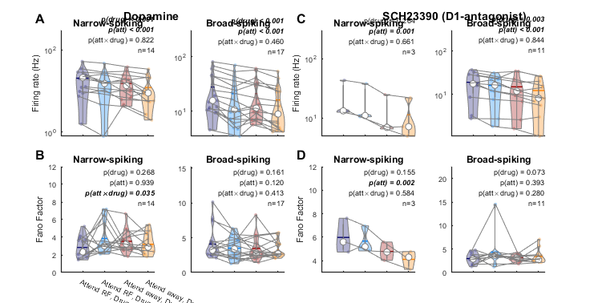

```matlab
% create suptitle
ha = axes('Position',[0 0 1 1],'Xlim',[0 1],'Ylim',[0 1],'Box','off','Visible','off','Units','normalized','clipping','off');
xpos_idx = 1:2:ncol;
for idrug = 1:num_drug
    xpos = (1/(ncol)) * xpos_idx(idrug);
    ht = text(xpos, 0.95, [label_drug{idrug} label_drug_ext{idrug}], 'FontSize', fSet.Fontsize_title * 1.2, 'HorizontalAlignment', 'center');
    ht.FontWeight = 'bold';
end

savefigname = fullfile(path_population, sprintf('violin_att_drug_unit'));
plotj_saveFig(savefigname, {'png', 'svg'})
```

## Post hoc comparisons: scatter plots and signed-rank tests

plotting and post-hoc tests

```matlab
ncol = 2 * (length(label_drug));
nrow = 2; % rate, FF

markerstyle = {'o','v'};
colors_scatter = get_colors('spikewidth');

idx_subplot = [1 2 ncol+1 ncol+2 ; 3 4 ncol+3 ncol+4] ;
idx_axlabel = [1 NaN 2 NaN ; 3 NaN 4 NaN]+2;

[fH, fSet] = plotj_initFig('figNum', 2, 'width', 20, 'height', 12, 'Journal',plot_conventions);
fSet.subplotGap = fSet.subplotGap .* [1 0.8];

[P, h_text] = deal( NaN(length(label_drug), 2, 2, 2) ); % drugtype, actvity-type, attention, drug-offon,
for idrug = 1:length(label_drug)

    iplot=0;
    for irow = 1:nrow

        if irow == 1
            % mean rate
            datatype = 'rate';
            ylim2use = [0.7 100];

            scale ='Log';
            x_text = 0.005;
            y_text = [0.9 0.4];
        elseif irow == 2
            % Fano factor
            datatype = 'FF';
            ylim2use = [0 10];

            scale ='Linear';
            x_text = 0.1;
            y_text = [0.95 0.1];
        end

        data2plot = att_table.(datatype);


        for iatt = 1:2
            iplot = iplot+1;

            subtightplot(nrow, ncol, idx_subplot(idrug, iplot), fSet.subplotGap, fSet.subplotMargin, fSet.subplotMargin)
            axH = plotj_initAx(fSet, 'axlabel', idx_axlabel(idrug, iplot), 'axlabelDisplacement', [0.05, 0.02]);
            hold on

            if irow==1 && iatt==1
                % sup-title
                set(gca,'units','normalized')
                text(100, 400, ['\bf ' label_drug{idrug}], 'FontSize', fSet.Fontsize_title, 'Interpreter', 'tex')
            end


            title(sprintf('Attend %s', label_attention{iatt}), 'FontSize', fSet.Fontsize_title)

            for iunitc = 1:2

                % unit selection
                idx_unit = get_unit_selectivity(att_table, selectivity_criterium, {'drug',label_drug(idrug)});
                idx_att = att_table.attention == label_attention{iatt};
                idx_unit_class = att_table.unit_class == label_unitclass{iunitc};

                unit2plot = idx_unit ...
                    & idx_att ...
                    & idx_unit_class;

                % extract data
                tmp_data = [data2plot(unit2plot & att_table.drug_on==label_drug_onoff{1}) ...
                    data2plot(unit2plot & att_table.drug_on==label_drug_onoff{2})];


                plotj_scatter(tmp_data, ...
                    'markerStyle', markerstyle(iunitc), 'MarkerSize', markersize, ...
                    'markerFaceColor', colors_scatter(iunitc,:), 'markerFaceAlpha', 0.5, ...
                    'markerEdgeColor', colors_scatter(iunitc,:), 'markerEdgeAlpha', 0.5, ...
                    'axislimit', ylim2use);

                % stats
                P(idrug,irow,iatt,iunitc) = compare_means(tmp_data(:,1), tmp_data(:,2), 1, 'rank');

                % effect size
                d = computeCohen_d(tmp_data(:,2), tmp_data(:,1), 'paired');

                % mean difference
                delta_data = tmp_data(:,2)-tmp_data(:,1);

                axis square
                p_string = get_significance_strings(P(idrug,irow,iatt,iunitc), 'rounded', 0);

                % print result
                fprintf('%s: %s, %s, attend %s: delta-%s %1.2f +- %1.2f, %s, Cohens''s d = %1.2f\n', ...
                    datatype, ...
                    label_drug{idrug}, ...
                    label_unitclass{iunitc}, ...
                    label_attention{iatt}, ...
                    datatype, ...
                    mean(delta_data), ...
                    std(delta_data)/sqrt(length(tmp_data)), ...
                    p_string, ...
                    d)

                % plot text
                tmp_x = get(gca,'xlim');
                tmp_y = get(gca,'ylim');

                x_pos = get_value_range(tmp_x, x_text);
                y_pos = get_value_range(tmp_y, y_text(1)-y_text(2)*(iunitc-1));

                h_text(idrug,irow,iatt,iunitc) = text(x_pos, y_pos, ...
                    sprintf('%s', p_string), ...
                    'Color', colors_scatter(iunitc,:));

                if iatt==2

                    x_pos = get_value_range(tmp_x, 0.6);
                    y_pos = get_value_range(tmp_y, 0.1+0.1*(iunitc-1));

                    text(x_pos, y_pos, sprintf('%s (n=%d)', label_unitclass{iunitc}, length(tmp_data)), 'Color', colors_scatter(iunitc,:));
                end
            end


            xlim(ylim2use)
            ylim(ylim2use)
            set(gca,'YScale', scale, 'XScale', scale)
            % %     set(gca,'', [1 10 100])

            if irow == 1
                set(gca,'Xtick', [1 10 100], 'XTickLabel', [1 10 100])
                set(gca,'Ytick', [1 10 100], 'YTickLabel', [1 10 100])

                xlabel('Firing rate no drug (Hz)','FontSize', fSet.Fontsize_text)

                if idrug==1 && iatt==1
                    ylabel('Firing rate drug (Hz)','FontSize', fSet.Fontsize_text)
                end
            elseif irow == 2
                xlabel('Fano Factor no drug','FontSize', fSet.Fontsize_text)
                if idrug==1 && iatt==1
                    ylabel('Fano Factor drug','FontSize', fSet.Fontsize_text)
                end
            end
        end
    end
end
```

rate: Dopamine, Narrow, attend Attend RF: delta-rate 3.60 +- 1.12, p = 0.009, Cohens's d = 0.86 rate: Dopamine, Broad, attend Attend RF: delta-rate 6.71 +- 1.22, p < 0.001, Cohens's d = 1.33 rate: Dopamine, Narrow, attend Attend away: delta-rate 3.22 +- 1.06, p = 0.009, Cohens's d = 0.81 rate: Dopamine, Broad, attend Attend away: delta-rate 4.92 +- 1.26, p < 0.001, Cohens's d = 0.95 FF: Dopamine, Narrow, attend Attend RF: delta-FF -1.03 +- 0.58, p = 0.119, Cohens's d = -0.47 FF: Dopamine, Broad, attend Attend RF: delta-FF 0.59 +- 0.39, p = 0.174, Cohens's d = 0.37 FF: Dopamine, Narrow, attend Attend away: delta-FF 0.33 +- 0.30, p = 0.326, Cohens's d = 0.30 FF: Dopamine, Broad, attend Attend away: delta-FF 0.16 +- 0.31, p = 0.927, Cohens's d = 0.12 rate: SCH23390, Narrow, attend Attend RF: delta-rate 3.19 +- 1.14, p = 0.250, Cohens's d = 1.62 rate: SCH23390, Broad, attend Attend RF: delta-rate 3.02 +- 0.99, p = 0.010, Cohens's d = 0.92 rate: SCH23390, Narrow, attend Attend away: delta-rate 1.44 +- 0.89, p = 0.500, Cohens's d = 0.93 rate: SCH23390, Broad, attend Attend away: delta-rate 2.67 +- 1.13, p = 0.042, Cohens's d = 0.71 FF: SCH23390, Narrow, attend Attend RF: delta-FF 0.31 +- 0.39, p = 0.500, Cohens's d = 0.47 FF: SCH23390, Broad, attend Attend RF: delta-FF -1.36 +- 0.98, p = 0.206, Cohens's d = -0.42 FF: SCH23390, Narrow, attend Attend away: delta-FF 0.67 +- 0.39, p = 0.500, Cohens's d = 1.00 FF: SCH23390, Broad, attend Attend away: delta-FF -0.34 +- 0.39, p = 0.638, Cohens's d = -0.26

[interactive chart not shown]

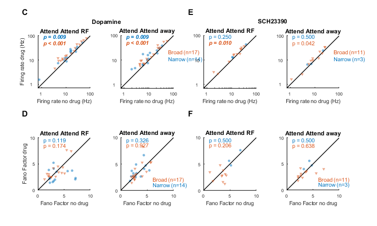

```matlab
[p_fdr, p_masked] = FDR(P, 0.05);
plotj_text_emphasise(h_text, p_masked, 'italic');
plotj_text_emphasise(h_text, p_masked, 'bold');


savefigname = fullfile(path_population, sprintf('mean_rate_FF_drug'));
plotj_saveFig(savefigname, {'png', 'svg'})
```

## Attend ROC, drug/no drug, narrow/broad. DrugMI-ejecCurrent

```matlab
% datatype for dose-response curve
datatype = 'MI';
% datatype = 'AUROC';
% datatype = 'gain_log';

colors = get_colors('spikewidth');
markerstyle = {'o','o'};


idx_group = 1;

ncol = length(label_drug);
nrow = 2;

[fH, fSet] = plotj_initFig('width', 20, 'height', 14, 'Journal',plot_conventions);
fSet.subplotGap = fSet.subplotGap.*[1.2 .8];

axislim = [0.25 0.9];
[P, h_text] = deal( NaN(length(label_drug), 2) ); % drugtype, unit-type,
[P_roc, h_text_roc] = deal( NaN(length(label_drug), 2) ); % drugtype, unit-type,
iplot=0;
for idrug = 1:length(label_drug)
    iplot = iplot+1;

    % unit selection
    idx_unit = get_unit_selectivity(att_table, selectivity_criterium, {'drug',label_drug(idrug)});

    % subplot axis
    h_ax_subplot = subtightplot(nrow, ncol, iplot, fSet.subplotGap, fSet.subplotMargin, fSet.subplotMargin);
    plotj_initAx(fSet, 'axlabel', idrug, 'axlabelDisplacement', [0.01, 0.02]);
    hold on

    title([label_drug{idrug} label_drug_ext{idrug}], 'FontSize', fSet.Fontsize_title)

    % inset axis
    pos = get(h_ax_subplot, 'Position');
    h_ax_inset = axes('Position', [pos(1)+0.28 pos(2)+0.035 0.1 0.11]) ; % inset
    plotj_initAx(fSet);
    hold on

    % lme
    for iunitc = 1:2

        set(fH, 'currentaxes', h_ax_subplot);

        unit2plot = idx_unit & att_table.unit_class==label_unitclass(iunitc);

        % get data - AUROC
        idx_cond = att_table.attention=='Attend RF';

        idx = unit2plot & idx_cond;
        tmp_data = zeros(length(find(idx))/2,1);
        tmp_data(:,1) = att_table.roc(idx & att_table.drug_on=='Drug off');
        tmp_data(:,2) = att_table.roc(idx & att_table.drug_on=='Drug on');

%         [bf10,p,CI,stats] = bf.ttest(tmp_data(:,1),tmp_data(:,2))
        plotj_scatter(tmp_data, ...
            'markerStyle', markerstyle, 'MarkerSize', markersize, ...
            'markerFaceColor', colors(iunitc,:), 'markerFaceAlpha', 0.5, ...
            'markerEdgeColor', colors(iunitc,:), 'markerEdgeAlpha', 0.5, ...
            'axislimit', axislim);
        % stats
        P(idrug,iunitc) = compare_means(tmp_data(:,1),tmp_data(:,2), 1, 'rank');

        axis square
        p_string = get_significance_strings(P(idrug,iunitc), 'rounded', 0);

        % mean difference
        delta_data = tmp_data(:,2)-tmp_data(:,1);

        % effect size
        d = computeCohen_d(tmp_data(:,2), tmp_data(:,1), 'paired');

        % print result
        fprintf('%s: %s, %s, delta-%s %1.2f +- %1.2f, %s, Cohens''s d = %1.2f\n', ...
            'AUROC', ...
            label_drug{idrug}, ...
            label_unitclass{iunitc}, ...
            'AUROC', ...
            mean(delta_data), ...
            std(delta_data)/sqrt(size(tmp_data,1)), ...
            p_string, ...
            d)

        % set text
        tmp_x = get(gca,'xlim');
        tmp_y = get(gca,'ylim');

        x_pos = get_value_range(tmp_x, 0.05);
        y_pos = get_value_range(tmp_y, 0.95 - 0.07 * (iunitc-1));

        h_text(idrug,iunitc) = text(x_pos, y_pos, ...
            sprintf('%s, %s (n=%d)', p_string, label_unitclass{iunitc}, size(tmp_data,1)), ...
            'Color', colors(iunitc,:), 'FontSize', fSet.Fontsize_ax);

        % inset
        % -----
        idx = tmp_data(:,1)<0.5;
        tmp_data(idx,:) = 1-tmp_data(idx,:);
%         [bf10,p,CI,stats] = bf.ttest(tmp_data(:,1),tmp_data(:,2))
        P_roc(idrug,iunitc) = compare_means(tmp_data(:,1),tmp_data(:,2), 1, 'rank');

        bar_data = diff(tmp_data,1,2);

        bar_y = mean(bar_data);
        bar_y_err = std(bar_data)/sqrt(length(bar_data));

        % plot
        set(fH, 'currentaxes', h_ax_inset);
        h_scatter = scatter(iunitc + (rand(length(bar_data),1)-0.5)*0.1, bar_data, ...
            '.', 'MarkerFaceColor', colors(iunitc,:),'MarkerEdgeColor', colors(iunitc,:));
        h_scatter.MarkerFaceAlpha = 0.5;
        h_scatter.MarkerEdgeAlpha = 0.5;

        plot(iunitc + [-0.25 0.25], [bar_y bar_y], 'Color', colors(iunitc,:), 'linew', fSet.LineWidth+1)
        plot(iunitc + [0 0], bar_y + [-bar_y_err bar_y_err], 'Color', colors(iunitc,:), 'linew', fSet.LineWidth)

        p_string = get_significance_strings(P_roc(idrug,iunitc), 'rounded', 0);

        % mean difference
        delta_data = tmp_data(:,2)-tmp_data(:,1);

        % effect size
        d = computeCohen_d(tmp_data(:,2), tmp_data(:,1), 'paired');

        % print result
        fprintf('%s: %s, %s, delta-%s %1.2f +- %1.2f, %s, Cohens''s d = %1.2f\n', ...
            'AUROC-CORRECT', ...
            label_drug{idrug}, ...
            label_unitclass{iunitc}, ...
            'AUROC', ...
            mean(delta_data), ...
            std(delta_data)/sqrt(size(tmp_data,1)), ...
            p_string, ...
            d)

        % set text
        % tmp_y = get(gca,'ylim');
        %y_pos = get_value_range(tmp_y, 0.95);
        y_pos = 0.1*idrug;

        h_text_roc(idrug,iunitc) = text(iunitc+0.1, y_pos, ...
            p_string, ...
            'Color', colors(iunitc,:), ...
            'FontSize', fSet.Fontsize_ax);
    end

    set(h_ax_inset, 'XTick', [1 2], 'XTickLabel', label_unitclass)
%     ylabel(h_ax_inset, [plotj_symbol('Delta') ' | AUROC-0.5 |'],'FontSize', fSet.Fontsize_text)
    ylabel(h_ax_inset, [plotj_symbol('Delta') ' AUROC-c'],'FontSize', fSet.Fontsize_text)

    xlabel(h_ax_subplot, 'Attention AUROC no drug','FontSize', fSet.Fontsize_text)
    if idrug==1
        ylabel(h_ax_subplot, 'Attention AUROC drug','FontSize', fSet.Fontsize_text)
    end
end
```

AUROC: Dopamine, Narrow, delta-AUROC 0.00 +- 0.02, p = 0.952, Cohens's d = 0.03

AUROC-CORRECT: Dopamine, Narrow, delta-AUROC -0.01 +- 0.02, p = 0.542, Cohens's d = -0.16

AUROC: Dopamine, Broad, delta-AUROC -0.03 +- 0.01, p = 0.009, Cohens's d = -0.69

AUROC-CORRECT: Dopamine, Broad, delta-AUROC -0.02 +- 0.01, p = 0.080, Cohens's d = -0.38

AUROC: SCH23390, Narrow, delta-AUROC -0.03 +- 0.04, p = 0.750, Cohens's d = -0.54

AUROC-CORRECT: SCH23390, Narrow, delta-AUROC -0.03 +- 0.04, p = 0.750, Cohens's d = -0.54

AUROC: SCH23390, Broad, delta-AUROC -0.02 +- 0.04, p = 0.700, Cohens's d = -0.15

AUROC-CORRECT: SCH23390, Broad, delta-AUROC -0.04 +- 0.03, p = 0.278, Cohens's d = -0.33

```matlab
% FDR correction
[p_fdr, p_masked] = FDR(P, 0.05);
[p_fdr, p_masked_corr] = FDR(P_roc, 0.05);

plotj_text_emphasise(h_text, p_masked, 'italic');
plotj_text_emphasise(h_text, p_masked, 'bold');


% drugMI/attAUROC against ejection current

switch datatype
    case 'MI'
        v_drug_table = unstack(drug_table, 'MI', {'attention'}, 'GroupingVariables', {'unit','unit_class'}, 'VariableNamingRule', 'preserve');
        data2plot = mean([v_drug_table.("Attend RF") v_drug_table.("Attend away")],2);

        iunitc=[];

        ylabel2use = 'Drug modulation index';
        ylim2use = {[-0.5 0.5],[-0.4 0.2]};
    case 'AUROC'

        % get data - AUROC
        idx_cond = att_table.attention=='Attend RF';

        tmp_data = zeros(length(find(idx_cond))/2,1);
        tmp_data(:,1) = att_table.roc(idx_cond & att_table.drug_on=='Drug off');
        tmp_data(:,2) = att_table.roc(idx_cond & att_table.drug_on=='Drug on');

        data2plot = diff(tmp_data,1,2);

        iunitc = [];

        ylabel2use = [plotj_symbol('Delta') ' attention AUROC'];
        ylim2use = {[-0.25 0.3],[-0.25 0.3]};
    case 'gain_log'


        v_att_table = unstack(att_table, 'gain_log', {'attention_drug_on'}, 'GroupingVariables', {'unit','unit_class'}, 'VariableNamingRule', 'preserve');

        % difference in attentional modulation of gain variabiliy
        data2plot1 = (v_att_table.("Attend RF, Drug on") - v_att_table.("Attend away, Drug on")) ./ (v_att_table.("Attend RF, Drug on") + v_att_table.("Attend away, Drug on"));
        data2plot2 = (v_att_table.("Attend RF, Drug off") - v_att_table.("Attend away, Drug off")) ./ (v_att_table.("Attend RF, Drug off") + v_att_table.("Attend away, Drug off"));
        data2plot = data2plot1 - data2plot2;
        iunitc=[];

end

clear ax h
for idrug = 1:ncol
    clear text_legend
    iplot=iplot+1;

    idx_unit = get_unit_selectivity(unitlist, selectivity_criterium, {'drug',label_drug(idrug)});

    ax(idrug) = subtightplot(nrow, ncol, iplot, fSet.subplotGap, fSet.subplotMargin, fSet.subplotMargin);
    plotj_initAx(fSet, 'axlabel', iplot, 'axlabelDisplacement', [0.01, 0.02]);
    hold on

    title([label_drug{idrug} label_drug_ext{idrug}], 'FontSize', fSet.Fontsize_title)

    if ~isempty(iunitc)
        unit2plot = idx_unit & unitlist.unit_class==label_unitclass(iunitc);
    else
        unit2plot = idx_unit;
    end
    length(find(unit2plot))

    % ejectionCurrent
    xlabel_event = 'Ejection Current';
    xlim2use = [17 90];

    if length(unique(unitlist.unit_class(unit2plot)))==1
        tmp_data = [unitlist.EjectCurrent(unit2plot)  data2plot(unit2plot)];
        hscat = plotj_scatter(tmp_data, ...
            'markerStyle', markerstyle, 'markerSize', markersize, ...
            'markerFaceColor', colors(iunitc,:), 'markerFaceAlpha', 0.5, ...
            'axislimit', [], ...
            'unityLine', 0);
        text_legend{1} = [label_unitclass{iunitc} ' (n=' num2str(length(find(unitlist.unit_class(idx_unit)==iunitc))) ')'];
    else
        tmp_data = [unitlist.EjectCurrent(unit2plot)  data2plot(unit2plot)];
        hscat = plotj_scatter(tmp_data, ...
            'dataIndex', grp2idx(unitlist.unit_class(unit2plot)), ...
            'markerStyle', markerstyle, 'MarkerSize', markersize, ...
            'markerFaceColor', (colors(1:2,:)), 'markerFaceAlpha', [0.5 0.5], ...
            'markerEdgeColor', (colors(1:2,:)), 'markerEdgeAlpha', [0.5 0.5], ...
            'axislimit', [], ...
            'unityLine', 0);
        text_legend{1} = [label_unitclass{1} ' (n=' num2str(length(find(unitlist.unit_class(idx_unit)==label_unitclass(1)))) ')'];
        text_legend{2} = [label_unitclass{2} ' (n=' num2str(length(find(unitlist.unit_class(idx_unit)==label_unitclass(2)))) ')'];
    end

    data_table = table(unitlist.EjectCurrent_centered(unit2plot), data2plot(unit2plot), 'VariableNames', {'x', 'y'});
    [stats2report, predict_data, stats, model] = fitlme_singleVar_sequential(data_table, 0);

    predict_data.x = predict_data.x + mean(unique(unitlist.EjectCurrent));

    switch datatype
        case 'MI'
            filename = fullfile(path_population, sprintf('doseResponse_drugMI_%s_%s.csv', label_drug{idrug}, selectivity_criterium));
        case 'AUROC'
            filename = fullfile(path_population, sprintf('doseResponse_attAUROC_%s_%s.csv', label_drug{idrug}, selectivity_criterium));
        case 'gain_log'
    end
    writetable(data_table, filename)

%     fprintf('Chi(%d) %1.2f, p = %1.3f\n', stats2report.deltaDF, stats2report.LRStat, stats2report.pValue)

    if any(strcmp('fit_mean', predict_data.Properties.VariableNames))
        h = plot(predict_data.x, predict_data.fit_mean, 'linewidth', fSet.LineWidth, 'color', [0.3 0.3 0.3]);
        h = plot(predict_data.x, predict_data.fit_CI_low, '--', 'linewidth', fSet.LineWidth_in, 'Color', [0.3 0.3 0.3]);
        h = plot(predict_data.x, predict_data.fit_CI_high, '--', 'linewidth', fSet.LineWidth_in, 'Color', [0.3 0.3 0.3]);
        [pstring_chi,starstring] = get_significance_strings(stats2report.pValue, 'rounded', 0);

        cond1 = exist([filename(1:end-4) '_R.csv'], 'file');
        cond2 = strcmpi(model,'quadratic');
        if cond1 && cond2
            utable = readtable([filename(1:end-4) '_R.csv']);

            if utable.usig==1
                pstring_chi = [pstring_chi ' (U^{+})'];
            else
                pstring_chi = [pstring_chi ' (U^{-})'];
            end
        end

    else
        pstring_chi = '';
    end


    switch model
        case 'linear'
            betaString = ['\beta' '_{1} = ' num2str(stats.Estimate, '%1.2e')];
        case 'quadratic'
            betaString = ['\beta' '_{2} = ' num2str(stats.Estimate, '%1.2e')];
        otherwise
            betaString = [];
    end

    axis square
    xlabel(xlabel_event, 'FontSize', fSet.Fontsize_text)
    if idrug==1
        ylabel(ylabel2use, 'FontSize', fSet.Fontsize_text)
    end

    if ~isempty(ylim2use)
        ylim(ylim2use{idrug})
    end
    if ~isempty(xlim2use)
        xlim(xlim2use)
    end

    % plot text indicating number of units
    set(gca, 'Units', 'normalized');

    tmp_x = get(gca,'xlim');
    tmp_y = get(gca,'ylim');

    x_pos = get_value_range(tmp_x, 0.6);
    y_pos(1) = get_value_range(tmp_y, 0.8);
    y_pos(2) = get_value_range(tmp_y, 0.9);

    text(x_pos, y_pos(1), text_legend{1}, 'FontSize', fSet.Fontsize_text, 'Color', colors(1,:))
    text(x_pos, y_pos(2), text_legend{2}, 'FontSize', fSet.Fontsize_text, 'Color', colors(2,:))

    % set ax param
    set(gca,'YDir','reverse')

    tmp_x = get(gca,'xlim');
    tmp_y = get(gca,'ylim');

    x_pos = get_value_range(tmp_x, 0.05);
    y_pos = get_value_range(tmp_y, 0.1);

    text(x_pos, y_pos, {betaString, pstring_chi }, 'fontsize', fSet.Fontsize_text, 'color', [0.3 0.3 0.3])

end
```

ans = 31

ans = 14

[interactive chart not shown]

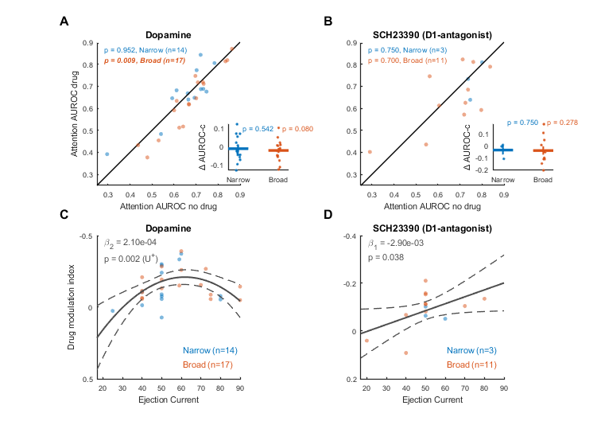

```matlab
savefigname = fullfile(path_population, sprintf('attAuroc_DrugResponseCurve'));
plotj_saveFig(savefigname, {'png', 'svg'})
```

## DrugMI-ejecCurrent across selectivity indices

```matlab
colors = get_colors('spikewidth');

datatype = 'MI';
% datatype = 'AUROC';


selectivity_criteria = {'none', 'att', 'dru', 'att&dru'};
label_criteria = {'No subselection', 'Attention-selective', 'Drug-selective', {'Attention & Drug', 'selective'}};

ncol = length(selectivity_criteria);
nrow = length(label_drug);
iplot = 0;

[fH, fSet] = plotj_initFig('width', 20, 'height', 10, 'Journal',plot_conventions);
fSet.subplotGap = fSet.subplotGap.*[1 .75];

idx_subplot = [1:ncol ; (ncol+1):ncol*2];

% drugMI/attAUROC against ejection current

switch datatype
    case 'MI'
        v_drug_table = unstack(drug_table, 'MI', {'attention'}, 'GroupingVariables', {'unit','unit_class'}, 'VariableNamingRule', 'preserve');
        data2plot = mean([v_drug_table.("Attend RF") v_drug_table.("Attend away")],2);

        iunitc=[];

        ylabel2use = 'Drug modulation index';
        ylim2use = [];
    case 'AUROC'
%         data2plot = squeeze(diff(rate_ROC.roc,1,2));
%         data2plot = squeeze(mean(data2plot(:,idx_attention_roc==1),2)); % average over relevant auroc conditions

        idx_cond = att_table.attention=='Attend RF';

        tmp_data = zeros(length(find(idx_cond))/2,1);
        tmp_data(:,1) = att_table.roc(idx_cond & att_table.drug_on=='Drug off');
        tmp_data(:,2) = att_table.roc(idx_cond & att_table.drug_on=='Drug on');

        data2plot = diff(tmp_data,1,2);


        iunitc = [];

        ylabel2use = [plotj_symbol('Delta') ' attention AUROC'];
        ylim2use = [-0.25 0.3];
end

[P,h_text] = deal(zeros(length(selectivity_criteria), length(label_drug)));
for icrit = 1:length(selectivity_criteria)

    selectivity_criterium = selectivity_criteria{icrit};

    clear ax h
    for idrug = 1:length(label_drug)
        clear text_legend
        iplot=iplot+1;

        idx_unit = get_unit_selectivity(unitlist, selectivity_criterium, {'drug',label_drug(idrug)});

        ax(idrug) = subtightplot(nrow, ncol, idx_subplot(iplot), fSet.subplotGap, fSet.subplotMargin, fSet.subplotMargin);
        if idrug==1
            plotj_initAx(fSet, 'axlabel', icrit);
        else
            plotj_initAx(fSet);
        end
        hold on

        if idrug==1
            % title([label_drug{idrug} label_drug_ext{idrug}], 'FontSize', fSet.Fontsize_title)
            h_title = title(label_criteria{icrit}, 'FontSize', fSet.Fontsize_title);
            set(h_title, 'Units', 'normalized');
            h_title.Position = h_title.Position+[0 0.2 0];
        end
        if ~isempty(iunitc)
            unit2plot = idx_unit & unitlist.unit_class==label_unitclass{iunitc};
        else
            unit2plot = idx_unit;
        end

        % ejectionCurrent
        xlabel_event = 'Ejection Current';
        xlim2use = [17 95];

        if length(unique(unitlist.unit_class(unit2plot)))==1
            tmp_data = [unitlist.EjectCurrent(unit2plot)  data2plot(unit2plot)];
            hscat = plotj_scatter(tmp_data, ...
                'markerStyle', {'.'}, 'markerSize', markersize, ...
                'markerFaceColor', colors(iunitc,:), 'markerFaceAlpha', 0.5, ...
                'axislimit', [], ...
                'unityLine', 0);
            text_legend{1} = [label_unitclass{iunitc} ' (n=' num2str(length(find(unit_class(idx_unit)==iunitc))) ')'];
        else
            tmp_data = [unitlist.EjectCurrent(unit2plot)  data2plot(unit2plot)];
            hscat = plotj_scatter(tmp_data, ...
                'dataIndex', grp2idx(unitlist.unit_class(unit2plot)), ...
                'markerStyle', {'o','o'}, 'MarkerSize', markersize, ...
                'markerFaceColor', (colors(1:2,:)), 'markerFaceAlpha', [0.5 0.5], ...
                'markerEdgeColor', (colors(1:2,:)), 'markerEdgeAlpha', [0.5 0.5], ...
                'axislimit', [], ...
                'unityLine', 0);
            text_legend{1} = [label_unitclass{1} ' (n=' num2str(length(find(unitlist.unit_class(idx_unit)==label_unitclass(1)))) ')'];
            text_legend{2} = [label_unitclass{2} ' (n=' num2str(length(find(unitlist.unit_class(idx_unit)==label_unitclass(2)))) ')'];
        end

        data_table = table(unitlist.EjectCurrent(unit2plot), data2plot(unit2plot), 'VariableNames', {'x', 'y'});
        [stats2report, predict_data, stats, model] = fitlme_singleVar_sequential(data_table, 0);
        P(icrit,idrug) = stats2report.pValue;

        switch datatype
            case 'MI'
                filename = fullfile(path_population, sprintf('doseResponse_drugMI_%s_%s.csv', label_drug{idrug}, selectivity_criteria{icrit}));
            case 'AUROC'
                filename = fullfile(path_population, sprintf('doseResponse_attAUROC_%s_%s.csv', label_drug{idrug}, selectivity_criteria{icrit}));
        end
        writetable(data_table, filename);

        fprintf('Chi(%d) %1.2f, p = %1.3f\n', stats2report.deltaDF, stats2report.LRStat, stats2report.pValue)

        if any(strcmp('fit_mean', predict_data.Properties.VariableNames))
            h = plot(predict_data.x, predict_data.fit_mean, 'linewidth', fSet.LineWidth, 'color', [0.3 0.3 0.3]);
            h = plot(predict_data.x, predict_data.fit_CI_low, '--', 'linewidth', fSet.LineWidth_in, 'Color', [0.3 0.3 0.3]);
            h = plot(predict_data.x, predict_data.fit_CI_high, '--', 'linewidth', fSet.LineWidth_in, 'Color', [0.3 0.3 0.3]);
            [pstring_chi,starstring] = get_significance_strings(stats2report.pValue, 'rounded', 0);

            cond1 = exist([filename(1:end-4) '_R.csv'], 'file');
            cond2 = strcmpi(model,'quadratic');
            if cond1 && cond2
                utable = readtable([filename(1:end-4) '_R.csv']);

                if utable.usig==1
                    pstring_chi = [pstring_chi ' (U^{+})'];
                else
                    pstring_chi = [pstring_chi ' (U^{-})'];
                end
            end

        else
            pstring_chi = '';
        end

        switch model
            case 'linear'
                betaString = ['\beta' '_{1} = ' num2str(stats.Estimate, '%1.2e')];
                %         model_color = colors(2,:);
            case 'quadratic'
                betaString = ['\beta' '_{2} = ' num2str(stats.Estimate, '%1.2e')];
            otherwise
                betaString = [];
        end

        axis square
        if idrug==length(label_drug)
            xlabel(xlabel_event, 'FontSize', fSet.Fontsize_text)
        end
        if icrit==1
            ylabel({label_drug{idrug},ylabel2use}, 'FontSize', fSet.Fontsize_text)
        end

        if ~isempty(ylim2use)
            ylim(ylim2use)
        end
        if ~isempty(xlim2use)
            xlim(xlim2use)
        end

        % plot text indicating number of units
        set(gca, 'Units', 'normalized');

        tmp_x = get(gca,'xlim');
        tmp_y = get(gca,'ylim');

        x_pos = get_value_range(tmp_x, 0.6);
        y_pos(1) = get_value_range(tmp_y, 0.8);
        y_pos(2) = get_value_range(tmp_y, 0.9);

        text(x_pos, y_pos(1), text_legend{1}, 'FontSize', fSet.Fontsize_text, 'Color', colors(1,:))
        text(x_pos, y_pos(2), text_legend{2}, 'FontSize', fSet.Fontsize_text, 'Color', colors(2,:))

        % set ax param
        set(gca,'YDir','reverse')

        % plot text with stats
        tmp_x = get(gca,'xlim');
        tmp_y = get(gca,'ylim');

        switch label_drug{idrug}
            case 'Dopamine'
                x_pos = get_value_range(tmp_x, 0.65);
                y_pos = get_value_range(tmp_y, 0.05);
            case 'SCH23390'
                x_pos = get_value_range(tmp_x, 0.05);
                y_pos = get_value_range(tmp_y, 0);
        end

        h_text(icrit,idrug) = text(x_pos, y_pos, {betaString, pstring_chi}, 'fontsize', fSet.Fontsize_text, 'color', [0.3 0.3 0.3]);

    end
end
```

Chi(1) 5.91, p = 0.015 Chi(1) 4.05, p = 0.044 Chi(1) 8.48, p = 0.004 Chi(1) 4.03, p = 0.045 Chi(1) 7.52, p = 0.006 Chi(1) 4.31, p = 0.038 Chi(1) 9.89, p = 0.002 Chi(1) 4.31, p = 0.038

[interactive chart not shown]

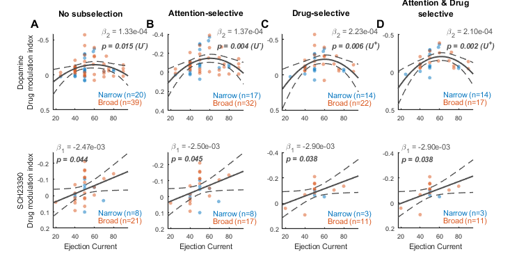

```matlab
% multiple comparison correction, individual models
[p_fdr, p_masked] = FDR(P, 0.05);
plotj_text_emphasise(h_text, p_masked, 'italic', 2);
plotj_text_emphasise(h_text, p_masked, 'bold', 2);

% save
savefigname = fullfile(path_population, sprintf('DrugResponseCurve_selection'));
plotj_saveFig(savefigname, {'png', 'svg'})
```

## plot gain, mean to variance relationship, separate for unit-types

```matlab
[colors, labels] = get_colors('att_drug');
[colors_violin, labels_violin, labels_violin_short] = get_colors('att_drug');
colors_violin = reshape(colors_violin, [4,3]);
labels_violin = reshape(labels_violin, [4,1]);

ncol = length(label_drug);
nrow = 2; % unit types

[fH, fSet] = plotj_initFig('width',20,'height',15,'Journal',plot_conventions);

clear legendText h
gain_table_full = [];

iplot=0;

xval_gain = 1:500;

for idrug = 1:length(label_drug)
    for iunitc = 1:length(unique(unitlist.unit_class))
        iplot = iplot+1;

        % unit selection
        idx_unit = get_unit_selectivity(att_table, selectivity_criterium, {'drug',label_drug(idrug)});
        idx_unit = idx_unit & att_table.unit_class==label_unitclass(iunitc);

        % subplot axis
        h_ax = subtightplot(nrow, ncol, iplot, fSet.subplotGap, fSet.subplotMargin, fSet.subplotMargin);
        if iunitc==1
            plotj_initAx(fSet, 'axlabel', idrug);
        else
            plotj_initAx(fSet);
        end
        hold on

        if idrug==1
            h_title = title([label_unitclass{iunitc} '-spiking'], 'FontSize', fSet.Fontsize_title);
        end

        gv = unstack(att_table(idx_unit,:), 'gv', {'attention_drug_on'}, 'GroupingVariables', {'unit','unit_class'}, 'VariableNamingRule', 'preserve');
        variable_names = gv.Properties.VariableNames;

        %%% scatter
        clear h
        for iatt_drug = 1:length(labels_violin)

            mus = [gv.(labels_violin{iatt_drug}).mus];
            s2s = [gv.(labels_violin{iatt_drug}).s2s];

            mus = mus(:);
            s2s = s2s(:);

            % get binomial fit
            rhat = nanmean([gv.(labels_violin{iatt_drug}).rhat]);

            gv_pop = GainVariability;
            gv_pop.rhat = rhat;
            m2v = gv_pop.pred_variance(xval_gain);

            % plot
            h(iatt_drug) = scatter(mus,s2s,fSet.MarkerSize*3,colors_violin(iatt_drug,:),'filled','MarkerFaceAlpha',0.5);
            plot(m2v.mean,m2v.variance,'Color',colors_violin(iatt_drug,:),'linew',fSet.LineWidth);
            xlim([0.8 max(xval_gain)])
            ylim([0.8 max(xval_gain)])
            plot([1e-10 max(s2s)*1.1],[1e-10 max(s2s)*1.1],'k','linew',1)
            set(gca,'xscale','log','yscale','log')
        end

        if idrug==length(label_drug)
            xlabel('Mean (spikes)','FontSize',fSet.Fontsize_text)
        end
        if iunitc==1
            ylabel({[label_drug{idrug} label_drug_ext{idrug}],'Variance (spikes^{2})'},'FontSize',fSet.Fontsize_text)
        end

        %%% violin

        % init axes
        pos = get(h_ax, 'Position');
        h_ax_inset = axes('Position', [pos(1)+0.22 pos(2)+0.03 0.16 0.15]) ; % inset
        plotj_initAx(fSet);
        hold on

        % unit selection
        idx_unit = get_unit_selectivity(att_table, selectivity_criterium, {'drug',label_drug(idrug)});
        idx_unit = idx_unit & att_table.unit_class==label_unitclass(iunitc);

        num_unit_plot = length(unique(att_table.unit(idx_unit)));

        fprintf('\t---------------------------------------------------')
        fprintf('\t Found %d units \n',  num_unit_plot)

        % extract smaller table
        v_att_table = att_table(idx_unit, ismember(att_table.Properties.VariableNames, {'gain_log','drug_on','attention','unit','attention_drug_on'}));

        % plot violin
        v = violinplot(v_att_table.gain_log, v_att_table.attention_drug_on, 'ShowMean', true);
        XTickLabel = get(gca,'XTickLabel');
        for iv = 1:length(v)
            v(iv).ScatterPlot.SizeData = 10;
            idx = strcmpi(XTickLabel(iv), labels_violin);
            v(iv).ViolinColor = colors_violin(idx,:);
        end
        set(gca,'XTickLabel',[])
        h_ax_inset.XAxis.Visible = 'off';

        % plot lines for each unit
        [data_x, data_y] = deal(NaN(num_unit_plot, length(length(v))));
        for iv = 1:length(v)
            if ~any(isnan(v_att_table.gain_log))
                % works if data is complete
                data_x(:,iv) = v(iv).ScatterPlot.XData;
                data_y(:,iv) = v(iv).ScatterPlot.YData;
            else
                % catch if nan values are present
                idx = strcmpi(XTickLabel(iv), labels_violin);

                idx_trial = v_att_table.attention_drug_on==labels_violin{idx};
                data_x(:,iv) = iv;
                data_y(:,iv) = v_att_table.gain_log(idx_trial);
            end
        end
        plot(data_x', data_y', 'Color', [0.5 0.5 0.5 0.3]);

        % fit model
        lme_population = fitlme(v_att_table,['gain_log ~ 1 + attention*drug_on + (1|unit)'],'DummyVarCoding','effects'); % fit interaction model with effect coding
        disp(lme_population.Coefficients)

        coefficients = lme_population.Coefficients;

        betas = coefficients.Estimate(2:end);
        betas_se = coefficients.SE(2:end);
        p_val = coefficients.pValue(2:end);

        %         p_string = get_significance_strings(p_val, 'rounded', 0);
        p_string = get_significance_strings(p_val, 'rounded', 0, 'factorstring', {'drug','att',sprintf('att%sdrug', '\times')});
        p_string{end+1} = ['n = ' num2str(num_unit_plot)];

        % plot text
        YLIM = get(gca,'ylim');
        set(gca, 'ylim', YLIM .* [1 1.25])

        tmp_x = get(gca,'xlim');
        tmp_y = get(gca,'ylim');

        x_pos = get_value_range(tmp_x, 0.95);
        y_pos = get_value_range(tmp_y, 1.3);

        h_text = text(x_pos, y_pos, p_string,'HorizontalAlignment','right');

        ylabel('log(\sigma^{2}_G )', 'FontSize', fSet.Fontsize_text)

        [p_masked] = p_val<0.05;
        p_masked = [p_masked ; false];
        plotj_text_emphasise(h_text, 1, 'italic', p_masked);
        plotj_text_emphasise(h_text, 1, 'bold', p_masked);
    end
end
```

Found 14 units

**Fixed effect coefficients: DFMethod = 'Residual', Alpha = 0.05** Name Estimate SE tStat DF pValue Lower Upper {'(Intercept)' } -1.6769 0.24109 -6.9553 47 9.5535e-09 -2.1619 -1.1919 {'drug_on_Drug on' } 0.23563 0.074521 3.1619 47 0.002744 0.085713 0.38555 {'attention_Attend RF' } -0.16931 0.074521 -2.272 47 0.027706 -0.31923 -0.019394 {'drug_on_Drug on:attention_Attend RF'} 0.097133 0.075694 1.2832 47 0.20571 -0.055145 0.24941

Found 17 units

**Fixed effect coefficients: DFMethod = 'Residual', Alpha = 0.05** Name Estimate SE tStat DF pValue Lower Upper {'(Intercept)' } -1.9154 0.1718 -11.149 63 1.5163e-16 -2.2587 -1.572 {'drug_on_Drug on' } 0.16573 0.045026 3.6809 63 0.00048392 0.075757 0.25571 {'attention_Attend RF' } -0.030159 0.045026 -0.66981 63 0.50543 -0.12014 0.059818 {'drug_on_Drug on:attention_Attend RF'} -0.031138 0.045026 -0.69156 63 0.49176 -0.12111 0.058839

Found 3 units

**Fixed effect coefficients: DFMethod = 'Residual', Alpha = 0.05** Name Estimate SE tStat DF pValue Lower Upper {'(Intercept)' } -1.1245 0.31895 -3.5257 8 0.0077812 -1.86 -0.38901 {'drug_on_Drug on' } 0.0032421 0.029576 0.10962 8 0.91541 -0.064961 0.071446 {'attention_Attend RF' } -0.1411 0.029576 -4.7706 8 0.0014075 -0.2093 -0.072895 {'drug_on_Drug on:attention_Attend RF'} 0.06162 0.029576 2.0834 8 0.070737 -0.0065831 0.12982

Found 11 units

**Fixed effect coefficients: DFMethod = 'Residual', Alpha = 0.05** Name Estimate SE tStat DF pValue Lower Upper {'(Intercept)' } -1.6587 0.34668 -4.7845 37 2.7399e-05 -2.3611 -0.95625 {'drug_on_Drug on' } 0.31791 0.088241 3.6027 37 0.00092093 0.13911 0.4967 {'attention_Attend RF' } -0.1319 0.088241 -1.4948 37 0.14346 -0.31069 0.046895 {'drug_on_Drug on:attention_Attend RF'} 0.17933 0.087884 2.0405 37 0.048482 0.0012596 0.3574

[interactive chart not shown]

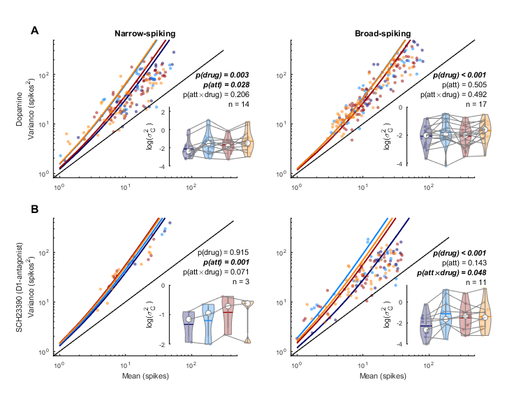

```matlab
savefigname = fullfile(path_population, sprintf('gain'));
plotj_saveFig(savefigname, {'png', 'svg'})
```

## plot behaviour

[interactive chart not shown]

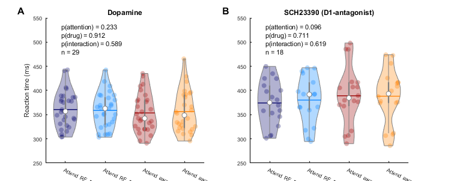

```matlab
mfactor = 1000; %multiplication_factor
colors = get_colors('att_drug');

ncol = length(label_drug);
nrow = 1;

ylim2plot = [250 550];

[fH, fSet] = plotj_initFig('width', 20, 'height', 8, 'Journal',plot_conventions);

clear legendText h
for idrug = 1:ncol

    idx_rec = strcmpi(recordinglist.Drug, label_drug(idrug));
    %
    subtightplot(nrow, ncol, idrug, fSet.subplotGap, fSet.subplotMargin, fSet.subplotMargin)
    plotj_initAx(fSet, 'axlabel', idrug, 'axlabelDisplacement', [0.07, 0.01]);
    hold on

    title([label_drug{idrug} label_drug_ext{idrug}], 'FontSize', fSet.Fontsize_title)

    iattDrug = 0;
    [RT_table,RT_mat,colors_mat] = deal([]);
    for iatt = 1:2
        for idrug_in = 1:2
            iattDrug = iattDrug+1;

            y = squeeze(mean(RT.RT(idx_rec,idrug_in,abs(idx_attention_cond-2)==iatt),3)) * mfactor;
            text_legend{iattDrug} = sprintf('%s, %s', label_attention{iatt}, label_drug_onoff{idrug_in});
            n = length(find(idx_rec));
            rec = (1:n)';
            cond = repmat(iatt,n,1);
            drug = repmat(idrug_in,n,1);
            RT_table = [RT_table ; table(rec,y,cond,drug,'VariableNames',{'recording','RT','attention','drug'})];
            RT_mat = [RT_mat, y];
            colors_mat = [colors_mat ; squeeze(colors(iatt,idrug_in,:))'];

        end
    end

    RT_table.attention = categorical(RT_table.attention);
    RT_table.drug = categorical(RT_table.drug);

    v = violinplot(RT_mat, text_legend, 'ShowMean', true);
    for iv = 1:length(v)
        v(iv).ViolinColor = colors_mat(iv,:);
    end

    % do stats
    % check with linear mixed effect model
    lme = fitlme(RT_table,['RT ~ 1 + (1|recording)'], 'DummyVarCoding', 'effects');% fit constant
    lme2 = fitlme(RT_table,['RT ~ attention + (1|recording)'], 'DummyVarCoding', 'effects'); % fit linear model with attention condition
    lme3 = fitlme(RT_table,['RT ~ attention + drug + (1|recording)'], 'DummyVarCoding', 'effects'); %  fit linear model with states
    lme4 = fitlme(RT_table,['RT ~ attention + drug + attention:drug + (1|recording)'], 'DummyVarCoding', 'effects'); % fit interaction

    [BETA,BETANAMES,STATS] = fixedEffects(lme4);

    % compare the model fits
    comp1 = compare(lme, lme2, 'CheckNesting',true); % compare linear to constant
    comp2 = compare(lme2, lme3, 'CheckNesting',true); %
    comp3 = compare(lme3, lme4, 'CheckNesting',true); %

    pstring = get_significance_strings([STATS.pValue(2:end)], 'rounded', 0, 'factorstring', {'attention', 'drug', 'interaction'});
    pstring{4} = ['n = ' num2str(length(find(idx_rec)))];

    ylim(ylim2plot)

    % plot text indicating number of units
    set(gca, 'Units', 'normalized');

    tmp_x = get(gca,'xlim');
    tmp_y = get(gca,'ylim');

    x_pos = get_value_range(tmp_x, 0.1);
    y_pos = get_value_range(tmp_y, 0.85);

    text(x_pos, y_pos, pstring, 'FontSize', fSet.Fontsize_text)

    if idrug==1
        ylabel('Reaction time (ms)', 'FontSize', fSet.Fontsize_text)
    end

    set(gca, 'xticklabelRotation', -25)

end


savefigname = fullfile(path_population, sprintf('RT'));
plotj_saveFig(savefigname, {'png', 'svg'})
```

## pupil timecourse

```matlab
events = {'stim', 'cue', 'dim'};
xlabel_event = {'Time from stimulus onset (ms)', 'Time from cue onset (ms)', 'Time from first-dimming (ms)'};
xlim2use = {[-200 1000], [-200 1000], [-1000 200]};
ylim2use = [-2.7 0.5];

ncol = length(events); % events
nrow = 2;%length(label_drug)-1;

timewinsize = 200;
timestep = 10;

[fH, fSet] = plotj_initFig('width', 20, 'height', 10, 'Journal',plot_conventions);
fSet.subplotGap = fSet.subplotGap ./ [1 2];
clear ax h legendText
iplot = 0;
for idrug = 1:nrow

    for ievent = 1:length(events)
        iplot = iplot+1;


        [pupil_timeseries, reclist] = get_population_data(recordinglist, 'pupil_timeseries', path_data, events{ievent});

        if nrow==length(label_drug)
            idx_rec = strcmpi(reclist.Drug, label_drug(idrug));
        else
            idx_rec = true(height(reclist),1);
        end
        nrecs = length(find(idx_rec));

        pupil2plot = squeeze(nanmean(pupil_timeseries.pupil(idx_rec,:,:,:),3));
        time = pupil_timeseries.time*1000;

        timecenters = time(1):timestep:time(end);
        p_drug = NaN(1,length(timecenters));

        clear legendText

        h_ax = subtightplot(nrow, ncol, iplot, fSet.subplotGap, fSet.subplotMargin, fSet.subplotMargin);
        if ievent==1
            plotj_initAx(fSet, 'axlabel', idrug, 'axlabelDisplacement', [0.07, 0.01]);
        else
            plotj_initAx(fSet);
        end
        hold on

        if (ievent~=1)
            axh = get(gca);
            axh.YTick = [];
            axh.YAxis.Visible = 'off'; % remove y-axis
        end

        ilegend = 0;

        for idrug_in = 1:2
            ilegend = ilegend+1;

            y = squeeze(nanmean(pupil2plot(:,idrug_in,:),1));
            y_err = squeeze(nanstd(pupil2plot(:,idrug_in,:),[],1))/sqrt(size(pupil2plot,1));

            h(ilegend) = boundedline(...
                time, ...
                y, ...
                y_err, ...
                'alpha', 'cmap', fSet.colors(idrug_in,:));
            set(h(ilegend), 'LineWidth', fSet.LineWidth)

            text_legend{ilegend} = sprintf('Drug %s', label_drug_onoff{idrug_in});

        end

        for itc = 1:length(timecenters)

            timewin = timecenters(itc) + [-timewinsize/2 timewinsize/2];
            idx_time = dsearchn(time(:), timewin(:));

            tmp_data = squeeze(nanmean(pupil2plot(:,:,idx_time(1):idx_time(2)),3));

            p_drug(itc) = compare_means(tmp_data(:,1), tmp_data(:,2), 1, 'rank');
        end

        [p_fdr, p_masked] = FDR( p_drug, 0.05);
        plotj_brokenVector(timecenters, ylim2use(1)*0.95, p_masked, 'linewidth', 5, 'color', [0.5 0.5 0.5]);

        if iplot==1
            hleg = legend(h, text_legend, 'autoupdate', 'off', 'FontSize', fSet.Fontsize_text, 'Box', 'Off');
        end
        xlim(xlim2use{ievent})
        ylim(ylim2use)
        plot([0 0], ylim, 'k','linew',1)

        if ievent==1
            ylabel('Pupil diameter (z-score)', 'FontSize', fSet.Fontsize_text)
        end
        if idrug==nrow
            xlabel(xlabel_event{ievent}, 'FontSize', fSet.Fontsize_text)
        end

        if ievent~=1
            set(gca,'yticklabel',[])
        end
        if nrow>1
            if ievent==2
                title([label_drug{idrug} label_drug_ext{idrug}], 'FontSize', fSet.Fontsize_title)
            end
        end

        if ievent==1
            text(h_ax, 500, -0.5, sprintf('n=%d',nrecs), 'FontSize', fSet.Fontsize_text)
        end

    end
end
```

Warning: Ignoring extra legend entries.

[interactive chart not shown]

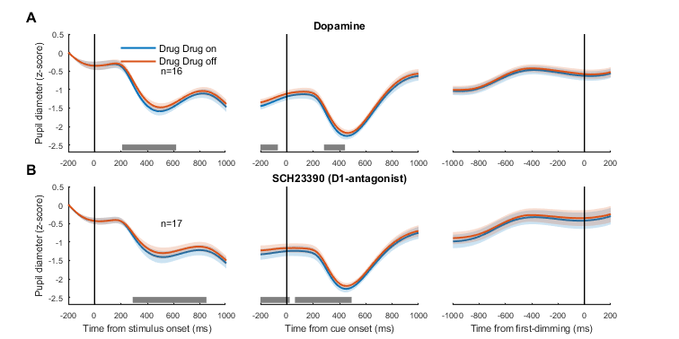

```matlab
savefigname = fullfile(path_population, sprintf('Pupil_timecourse'));
plotj_saveFig(savefigname, {'png', 'svg'})
```

## Pupil drug/no drug, scatter

```matlab
colors = get_colors('drug');

events = {'baseline', 'stim', 'cue', 'dim'};
event_title = {'Baseline','Stimulus evoked','Cue evoked','First-dimming'};

ncol = length(events); % events
nrow = 1;

xtext = [22 22];
ytext = [-0.45 -0.32];


[fH, fSet] = plotj_initFig('width', 20, 'height', 10, 'Journal',plot_conventions);
fSet.subplotGap = fSet.subplotGap/1.5;
clear ax h legendText

[P, h_text] = deal(NaN(length(events), length(label_drug)));
for ievent = 1:length(events)

    [pupil, reclist] = get_population_data(recordinglist, 'pupil_windows', path_data, events{ievent});

    axlim = [];

    subtightplot(nrow, ncol, ievent, fSet.subplotGap, fSet.subplotMargin, fSet.subplotMargin)
    plotj_initAx(fSet, 'axlabel', ievent+2, 'axlabelDisplacement', [0.05, 0.13]);
    hold on
    title(event_title{ievent}, 'FontSize', fSet.Fontsize_title)

    % significance testing
    text_p = cell(length(label_drug),1);
    for idrug = 1:length(label_drug)

        idx_rec = strcmpi(reclist.Drug, label_drug(idrug));

        pupil2plot = squeeze(nanmean(pupil.pupil(idx_rec,:,:),3));

        P(ievent,idrug) = compare_means(pupil2plot(:,1), pupil2plot(:,2), 1, 'rank');

        text_p{idrug} = get_significance_strings(P(ievent,idrug), 'rounded', 0);

        text_legend{idrug} = sprintf('%s (n=%d)', label_drug{idrug}, length(find(idx_rec)));

        % mean difference
        delta_data = pupil2plot(:,2)-pupil2plot(:,1);

        % effect size
        d = computeCohen_d(pupil2plot(:,2), pupil2plot(:,1), 'paired');

        % print result
        fprintf('%s: %s, delta-%s %1.2f +- %1.2f, %s, Cohens''s d = %1.2f\n', ...
            'PUPIL', ...
            label_drug{idrug}, ...
            'pupil', ...
            mean(delta_data), ...
            std(delta_data)/sqrt(length(find(idx_rec))), ...
            text_p{idrug}, ...
            d)

    end


    pupil2plot = squeeze(nanmean(pupil.pupil,3));
    h = plotj_scatter(pupil2plot, ...
        'dataIndex', idx_rec+1, ...
        'Markersize', markersize, 'markerStyle', {'o','s'}, ...
        'MarkerEdgeColor', colors, 'MarkerFaceColor', colors, ...
        'MarkerEdgeAlpha', [0.5 0.5] ,'MarkerFaceAlpha', [0.5 0.5]);

    %     set(gca,'ydir','reverse')
    axis square
    tmp_x = get(gca,'xlim');
    tmp_y = get(gca,'ylim');

    x_pos = get_value_range(tmp_x, 0.6);

    for idrug = 1:length(label_drug)

        y_pos = get_value_range(tmp_y, 0.2-0.1*(idrug-1));

        h_text(ievent,idrug) = text(x_pos, y_pos, text_p{idrug}, 'FontSize', fSet.Fontsize_text, 'color', colors(idrug,:));
    end

    if ievent==1
        ylabel({'Drug (z-score)'}, 'FontSize', fSet.Fontsize_text)
    end
    xlabel({'No drug (z-score)'}, 'FontSize', fSet.Fontsize_text)

    if ievent==4
        hleg = legend(h, text_legend, 'FontSize', fSet.Fontsize_text, 'Box', 'Off', 'Location', 'NorthEast');
        hleg.Position = hleg.Position + [0.05 0.3 0 0];
    end

end
```

PUPIL: Dopamine, delta-pupil 0.02 +- 0.04, p = 0.821, Cohens's d = 0.13 PUPIL: SCH23390, delta-pupil 0.01 +- 0.05, p = 0.890, Cohens's d = 0.04 PUPIL: Dopamine, delta-pupil 0.10 +- 0.02, p < 0.001, Cohens's d = 1.09 PUPIL: SCH23390, delta-pupil 0.10 +- 0.03, p = 0.004, Cohens's d = 0.79 PUPIL: Dopamine, delta-pupil 0.08 +- 0.03, p = 0.051, Cohens's d = 0.66 PUPIL: SCH23390, delta-pupil 0.07 +- 0.03, p = 0.031, Cohens's d = 0.62 PUPIL: Dopamine, delta-pupil 0.05 +- 0.03, p = 0.193, Cohens's d = 0.37 PUPIL: SCH23390, delta-pupil 0.06 +- 0.03, p = 0.023, Cohens's d = 0.54

Warning: Ignoring extra legend entries.

[interactive chart not shown]

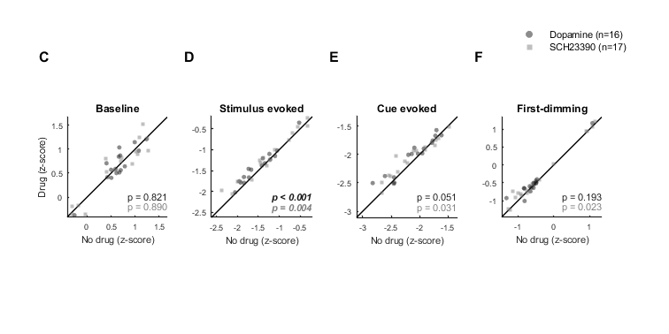

```matlab
[p_fdr, p_masked] = FDR(P, 0.05);
plotj_text_emphasise(h_text, p_masked, 'italic');
plotj_text_emphasise(h_text, p_masked, 'bold');

savefigname = fullfile(path_population, sprintf('Pupil_scatter'));
plotj_saveFig(savefigname, {'png', 'svg'})
```